# Micro4all workflow

## Introduction

This package is intended to record R functions we usually use in our laboratory for the *analysis of amplicon data*. The following tutorial has been created to show the main utilities of this package, as well as to make public our main workflow. We will cover several steps, including:

- Produce an amplicon sequence variant (ASV) table, making use of [dada2](https://benjjneb.github.io/dada2/tutorial.html)<sup>1</sup> package.
- Study microbial diversity ($\alpha$ and $\beta$ diversity).
- Get taxonomical profiles at *phylum* and *genus* level.
- Differential abundance analysis with ANCOMBC<sup>2</sup> package.
- Ordination graphics and environmental fitting of soil physicochemical parameters.

### Dataset

In this tutorial, we will use a bunch of sequences of our own. Specifically, we collected endosphere samples of 8 olive trees (Picual variety) from three different locations (let’s call them location 1, location 2 and location 3) and sequenced the V3-V4 region of the *16S rRNA* gene (with Illumina MiSeq technology) in order to study the bacterial community. These paired-end fastq files (already “demultiplexed” and without barcodes) can be download here. In this link you can also find a phyloseq object that will be used in environmental fitting section of this tutorial.

## Install package

```r
#devtools::install_github("nuriamw/micro4all")
library(micro4all)
```

# Produce an amplicon sequence variant (ASV) table.

The first part of this tutorial is mainly based in the information provided by `dada2` but with our own implementations. We will end this section with an ASV table, already cleaned and ready for diversity analysis.

## Prepare data: libraries and read sequences files

```r
library(dada2); packageVersion("dada2")
```

```
#> [1] '1.20.0'
```

```r
library(ShortRead);packageVersion("ShortRead")
```

```
#> [1] '1.50.0'
```

```r
library(devtools);packageVersion("devtools")
```

```
#> [1] '2.4.2'
```

```r
library(ggplot2);packageVersion("ggplot2")
```

```
#> [1] '3.3.5'
```

```r
library(tidyverse);packageVersion("tidyverse")
```

```
#> [1] '1.3.1'
```

```r
path <- "~/Escritorio/data_micro4all/" # CHANGE ME to the directory containing the fastq files after unzipping.
list.files(path)
```

```
#>  [1] "ASV_length_nochim.rds"    "cutadapt"                 "figaro"
#>  [4] "filtN"                    "L1-1_S102_R1_001.fastq"   "L1-1_S102_R2_001.fastq"
#>  [7] "L1-2_S112_R1_001.fastq"   "L1-2_S112_R2_001.fastq"   "L1-3_S121_R1_001.fastq"
#> [10] "L1-3_S121_R2_001.fastq"   "L1-4_S130_R1_001.fastq"   "L1-4_S130_R2_001.fastq"
#> [13] "L1-5_S138_R1_001.fastq"   "L1-5_S138_R2_001.fastq"   "L1-6_S145_R1_001.fastq"
#> [16] "L1-6_S145_R2_001.fastq"   "L1-7_S152_R1_001.fastq"   "L1-7_S152_R2_001.fastq"
#> [19] "L1-8_S159_R1_001.fastq"   "L1-8_S159_R2_001.fastq"   "L2-1_S139_R1_001.fastq"
#> [22] "L2-1_S139_R2_001.fastq"   "L2-2_S146_R1_001.fastq"   "L2-2_S146_R2_001.fastq"
#> [25] "L2-3_S153_R1_001.fastq"   "L2-3_S153_R2_001.fastq"   "L2-4_S160_R1_001.fastq"
#> [28] "L2-4_S160_R2_001.fastq"   "L2-5_S104_R1_001.fastq"   "L2-5_S104_R2_001.fastq"
#> [31] "L2-6_S114_R1_001.fastq"   "L2-6_S114_R2_001.fastq"   "L2-7_S123_R1_001.fastq"
#> [34] "L2-7_S123_R2_001.fastq"   "L2-8_S132_R1_001.fastq"   "L2-8_S132_R2_001.fastq"
#> [37] "L3-1_S136_R1_001.fastq"   "L3-1_S136_R2_001.fastq"   "L3-2_S143_R1_001.fastq"
#> [40] "L3-2_S143_R2_001.fastq"   "L3-3_S150_R1_001.fastq"   "L3-3_S150_R2_001.fastq"
#> [43] "L3-4_S157_R1_001.fastq"   "L3-4_S157_R2_001.fastq"   "L3-5_S101_R1_001.fastq"
#> [46] "L3-5_S101_R2_001.fastq"   "L3-6_S111_R1_001.fastq"   "L3-6_S111_R2_001.fastq"
#> [49] "L3-7_S120_R1_001.fastq"   "L3-7_S120_R2_001.fastq"   "L3-8_S129_R1_001.fastq"
#> [52] "L3-8_S129_R2_001.fastq"   "MOCK-1_S169_R1_001.fastq" "MOCK-1_S169_R2_001.fastq"
#> [55] "MOCK-2_S176_R1_001.fastq" "MOCK-2_S176_R2_001.fastq" "MOCK-3_S183_R1_001.fastq"
#> [58] "MOCK-3_S183_R2_001.fastq" "nochim"                   "num_seqs.txt"
#> [61] "rdp_train_set_18_H.fa"    "tabla_otu_inicial.rds"    "taxa_rdp_16S.rds"
```

```r
## SORT FORWARD AND REVERSE READS SEPARETELY; forward and reverse fastq filenames have format: SAMPLENAME_R1_001.fastq and SAMPLENAME_R2_001.fastq ##
fnFs <- sort(list.files(path, pattern="_R1_001.fastq", full.names = TRUE))
fnRs <- sort(list.files(path, pattern="_R2_001.fastq", full.names = TRUE))
# Extract sample names, assuming filenames have format: SAMPLENAME_XXX.fastq
sample.names <- sapply(strsplit(basename(fnFs), "_"), `[`, 1)
```

## Check sequences quality

A crucial step in any sequencing analysis pipeline is quality checking and we will use several approaches. First, we will generate a table with the number of reads in each sample, just to check if anything went wrong during sequencing process.

```r
#### COUNT NUMBER OF READS IN EACH SAMPLE BEFORE FILTERING ####
raw_reads_count <- NULL

for (i in 1:length(fnFs)){

  raw_reads_count <- rbind(raw_reads_count, length(ShortRead::readFastq(fnFs[i])))}

rownames(raw_reads_count)<- sample.names
colnames(raw_reads_count)<- "Number of reads"

min(raw_reads_count)
```

```
#> [1] 66426
```

```r
max(raw_reads_count)
```

```
#> [1] 125873
```

As we can see, even the minimum number of sequences is good enough for our analysis. We can also check with a histogram the distribution of sequences length.

```r
#### HISTOGRAM WITH SEQUENCE LENGTH DISTRIBUTION ####

reads <- ShortRead::readFastq(fnFs)

counts= NULL
uniques <- unique(reads@quality@quality@ranges@width)

for (i in 1:length(uniques)) {
  counts<- rbind(counts,length(which(reads@quality@quality@ranges@width==uniques[i])))

}

histogram <-  cbind(uniques,counts)
colnames(histogram) <- c("Seq.length", "counts")

#Check histogram matrix
head(histogram[order(histogram[,1],decreasing = TRUE),]) #Most sequences fall in expected sequence length
```

```
#>      Seq.length  counts
#> [1,]        301 2154642
#> [2,]        300   71753
#> [3,]        299   16251
#> [4,]        298   61651
#> [5,]        297   10119
#> [6,]        296     377
```

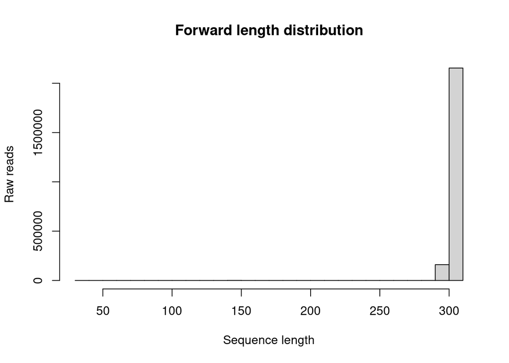

```r
# PLOT HISTOGRAM
hist(reads@quality@quality@ranges@width, main="Forward length distribution", xlab="Sequence length", ylab="Raw reads")
```

Moreover, `plotQualityProfile` function of `dada2` is very useful for a quick visualization of sequences quality profile.

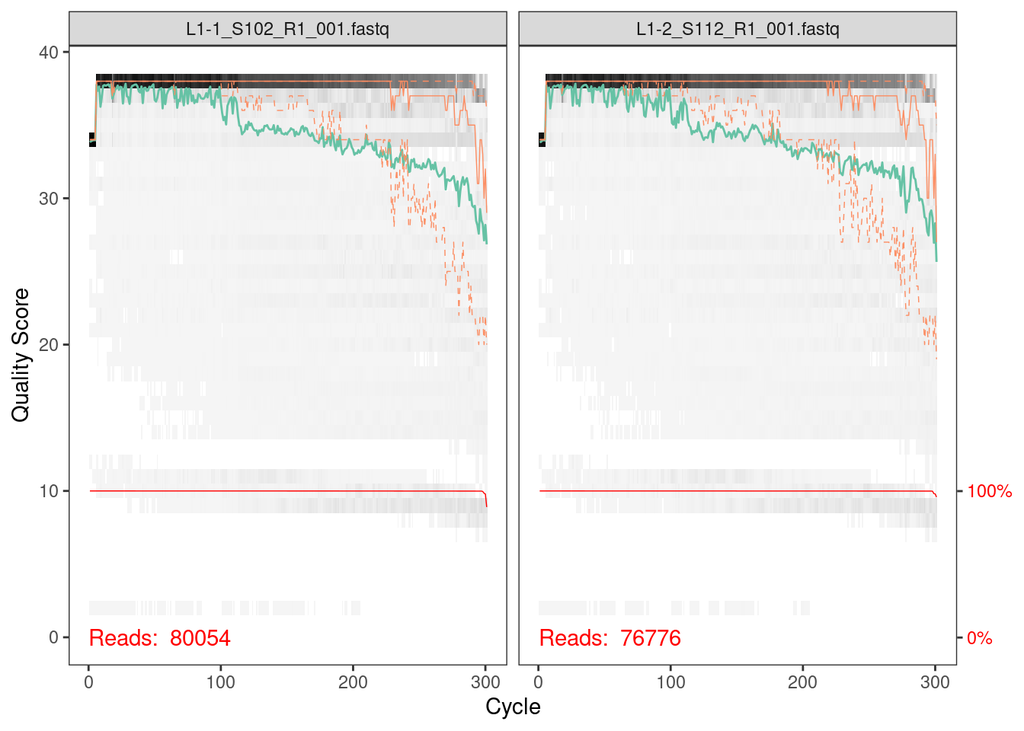

```r
## VIEW AND SAVE QUALITY PLOT FOR FW AND RV ##
plotQualityProfile(fnFs[1:2])
```

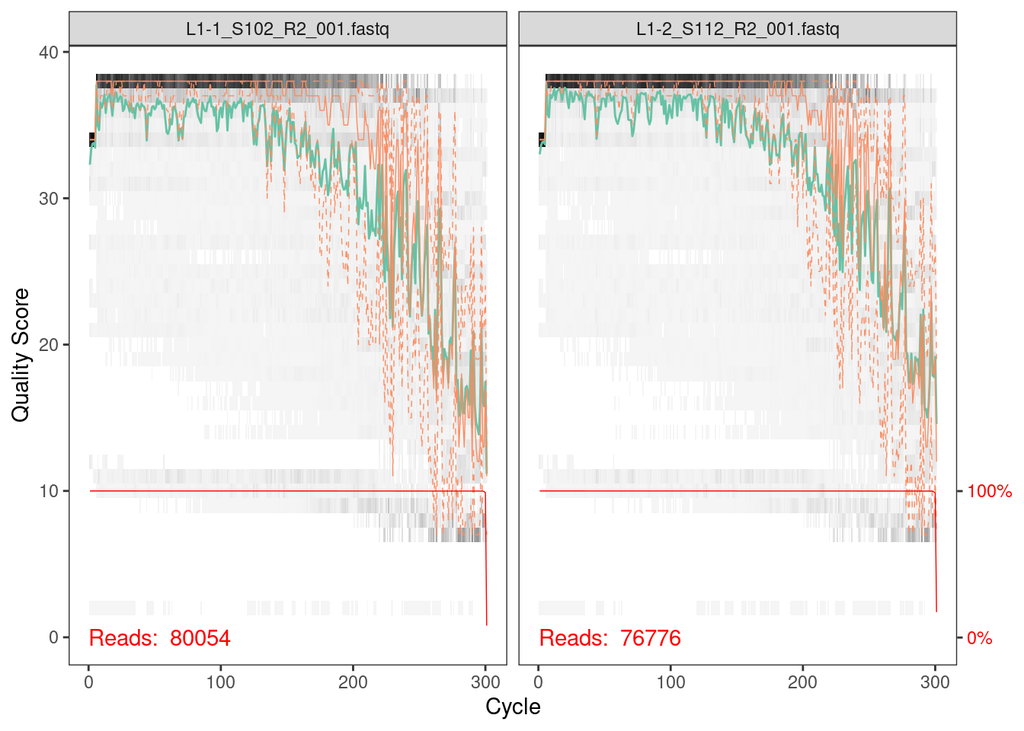

```r
plotQualityProfile(fnRs[1:2])
```

## Figaro: selection of trimming parameters

In this tutorial, we will use the [Figaro](https://github.com/Zymo-Research/figaro#figaro)<sup>3</sup> tool. This tool makes the selection of trimming parameters for dada2 more objective. Sadly, Figaro has not yet been updated to lead with variations in sequence lengths. We will solve this following author’s recommendation (which you can find [here](https://github.com/Zymo-Research/figaro/issues/37)). It consist on performing a pre-trimming step at about 295 bp. Let’s see how it works!

```r
#### FIGARO ####

##FILTER READS
figFs <- file.path(path, "figaro", basename(fnFs))
figRs <- file.path(path, "figaro", basename(fnRs))

#### TRIMMING AT 295 pb ####
out.figaro <- filterAndTrim(fnFs, figFs, fnRs, figRs,
                     compress=TRUE, multithread=TRUE, truncLen=c(295,295)) #

##RUN FIGARO
figaro <- system(("python3 /home/programs/figaro/figaro/figaro.py -i ~/Escritorio/data_micro4all/figaro -o ~/Escritorio/data_micro4all/figaro -a 426 -f 17 -r 21"),
                 intern=TRUE) #path to figaro program -i path to input - path to output -a length of your amplicon without primers, -f primer forward length, -r primer reverse length


head(figaro)
```

```
#> [1] "Forward read length: 295"
#> [2] "Reverse read length: 295"
#> [3] "{\"trimPosition\": [279, 205], \"maxExpectedError\": [3, 2], \"readRetentionPercent\": 81.69, \"score\": 76.68937485688116}"
#> [4] "{\"trimPosition\": [278, 206], \"maxExpectedError\": [3, 2], \"readRetentionPercent\": 81.68, \"score\": 76.6750629722922}"
#> [5] "{\"trimPosition\": [277, 207], \"maxExpectedError\": [3, 2], \"readRetentionPercent\": 81.67, \"score\": 76.66838409281735}"
#> [6] "{\"trimPosition\": [280, 204], \"maxExpectedError\": [3, 2], \"readRetentionPercent\": 81.66, \"score\": 76.6617052133425}"
```

## Cutadapt: efficient removal of primers

Now that we have run Figaro and know at which position we should make the trimming, we can follow with primer removing. This will be done with [cutapat](https://cutadapt.readthedocs.io/en/stable/)<sup>4</sup> tool. Cutadapt should not be applied before Figaro because it can modify the quality profiles in which Figaro is based.

```r
#### IDENTIFY PRIMERS ####

FWD <- "CCTACGGGNBGCASCAG"  ## CHANGE ME to your forward primer sequence
REV <- "GACTACNVGGGTATCTAATCC"  ## CHANGE ME to your reverse primer sequence

## VERIFY PRESENCE AND ORENTATION OF PRIMERS ##
allOrients <- function(primer) {
  # Create all orientations of the input sequence
  require(Biostrings)
  dna <- DNAString(primer)  # The Biostrings works w/ DNAString objects rather than character vectors
  orients <- c(Forward = dna, Complement = Biostrings::complement(dna), Reverse = reverse(dna),
               RevComp = reverseComplement(dna))
  return(sapply(orients, toString))  # Convert back to character vector
}
FWD.orients <- allOrients(FWD)
REV.orients <- allOrients(REV)
FWD.orients
```

```
#>             Forward          Complement             Reverse             RevComp
#> "CCTACGGGNBGCASCAG" "GGATGCCCNVCGTSGTC" "GACSACGBNGGGCATCC" "CTGSTGCVNCCCGTAGG"
```

```r
REV.orients
```

```
#>                 Forward              Complement                 Reverse                 RevComp
#> "GACTACNVGGGTATCTAATCC" "CTGATGNBCCCATAGATTAGG" "CCTAATCTATGGGVNCATCAG" "GGATTAGATACCCBNGTAGTC"
```

```r
## REMOVE SEQUENCES WITH Ns BEFORE PRIMER CHECK ##
fnFs.filtN <- file.path(path, "filtN", basename(fnFs)) # Put N-filterd files in filtN/ subdirectory
fnRs.filtN <- file.path(path, "filtN", basename(fnRs))

filterAndTrim(fnFs, fnFs.filtN, fnRs, fnRs.filtN, maxN = 0, multithread = TRUE)

## COUNT THE APPEARENCE AND ORIENTATION OF PRIMERS ##
primerHits <- function(primer, fn) {
  # Counts number of reads in which the primer is found
  nhits <- vcountPattern(primer, sread(readFastq(fn)), fixed = FALSE)
  return(sum(nhits > 0))
}
rbind(FWD.ForwardReads = sapply(FWD.orients, primerHits, fn = fnFs.filtN[[1]]),
      FWD.ReverseReads = sapply(FWD.orients, primerHits, fn = fnRs.filtN[[1]]),
      REV.ForwardReads = sapply(REV.orients, primerHits, fn = fnFs.filtN[[1]]),
      REV.ReverseReads = sapply(REV.orients, primerHits, fn = fnRs.filtN[[1]]))
```

```
#>                  Forward Complement Reverse RevComp
#> FWD.ForwardReads   77589          0       0       0
#> FWD.ReverseReads       0          0       0      11
#> REV.ForwardReads       2          0       0      49
#> REV.ReverseReads   75892          0       0       0
```

At this point, and as it is explained in [dada2 ITS tutorial](https://benjjneb.github.io/dada2/ITS_workflow.html), we found what we expected to: the FWD primer appears in the forward reads in its forward orientation, but it also show up in some reverse reads in its reverse-complement orientation. Something similar occurs with reverse primer.

Now, let’s run cutadapt. We use argument ^ for anchoring primers. Moreover, we combine it with the *–discard-untrimed argument*. In this way, we make sure that a sequence is not retained if only the reverse primer is found. Forward and reverse primers should be present in order to keep the sequences.

```r
cutadapt <- "/usr/local/bin/cutadapt" #path to cutadapt

system2(cutadapt, args = c("--version")) # Run shell commands from R

##Create path to cutadapt sequences
path.cut <- file.path(path, "cutadapt")
if(!dir.exists(path.cut)) dir.create(path.cut)

fnFs.cut <- file.path(path.cut, basename(fnFs))
fnRs.cut <- file.path(path.cut, basename(fnRs))


##Produce arguments for cutadapt
FWD.RC <- dada2:::rc(FWD)
REV.RC <- dada2:::rc(REV)

# Trim FWD and the reverse-complement of REV off of R1 (forward reads)
R1.flags <- paste0("-a", " ", "^",FWD,"...", REV.RC)

# Trim REV and the reverse-complement of FWD off of R2 (reverse reads)
R2.flags <- paste0("-A"," ","^", REV, "...", FWD.RC)


# Run Cutadapt

for(i in seq_along(fnFs)) {
  system2(cutadapt, args = c(R1.flags, R2.flags, "-n", 2,"-m", 1, # -n 2 required to remove FWD and REV from reads
                             #-m 1 is required to remove empty sequences for plotting quality plots
                             "--discard-untrimmed",
                             "-j",0,#automatically detect number of cores
                             "-o", fnFs.cut[i], "-p", fnRs.cut[i], # output files
                             fnFs.filtN[i], fnRs.filtN[i],# input files
                             "--report=minimal")) #Report minimal reports a summary

}
```

Let’s see if cutadapt has properly removed the primers

```r
##CHECK PRESENCE OF PRIMERS IN CUTADAPTED SEQUENCES##
rbind(FWD.ForwardReads = sapply(FWD.orients, primerHits, fn = fnFs.cut[[1]]),
      FWD.ReverseReads = sapply(FWD.orients, primerHits, fn = fnRs.cut[[1]]),
      REV.ForwardReads = sapply(REV.orients, primerHits, fn = fnFs.cut[[1]]),
      REV.ReverseReads = sapply(REV.orients, primerHits, fn = fnRs.cut[[1]]))
```

```
#>                  Forward Complement Reverse RevComp
#> FWD.ForwardReads       8          0       0       0
#> FWD.ReverseReads       0          0       0       0
#> REV.ForwardReads       0          0       0       0
#> REV.ReverseReads       0          0       0       0
```

```r
cutFs <- sort(list.files(path.cut, pattern = "_R1_001.fastq", full.names = TRUE))
cutRs <- sort(list.files(path.cut, pattern = "_R2_001.fastq", full.names = TRUE))
```

As we can see, there are still some forward primers to be found on forward reads. We should not worry about that. `Cutadapt` and `primerHits` have different ways to look for primers in the sequence. Moreover, if primers are still to be found in low quality sequences, they will probably be removed in next steps.

It’s time to apply Figaro trimming parameters!

## Filter and trim sequences

```r
### FILTER AND TRIM SEQUENCES ACCORDING TO FIGARO ####

## Place filtered files in filtered/ subdirectory
filtFs <- file.path(path.cut, "filtered", basename(cutFs))
filtRs <- file.path(path.cut, "filtered", basename(cutRs))

out <- filterAndTrim(cutFs, filtFs, cutRs, filtRs, truncLen=c(279,205),
                     maxN=0, maxEE=c(3,2), truncQ=2, rm.phix=TRUE,
                     compress=TRUE, multithread=TRUE, minLen=50)
```

To continue with, we will apply the main core of DADA2 package. As it is very well detailed in its tutorial, we will not make a lot of comments about it

## Learn error rates

```r
#### LEARN ERROR RATES ####
errF <- learnErrors(filtFs, multithread=T, verbose=1 ) #
```

```
#> 111572937 total bases in 399903 reads from 6 samples will be used for learning the error rates.
#> Initializing error rates to maximum possible estimate.
#> selfConsist step 1 ......
#>    selfConsist step 2
#>    selfConsist step 3
#>    selfConsist step 4
#>    selfConsist step 5
#>    selfConsist step 6
#>    selfConsist step 7
#>    selfConsist step 8
#>    selfConsist step 9
#> Convergence after  9  rounds.
```

```r
errR <- learnErrors(filtRs, multithread=T, verbose=1) #
```

```
#> 108371200 total bases in 528640 reads from 8 samples will be used for learning the error rates.
#> Initializing error rates to maximum possible estimate.
#> selfConsist step 1 ........
#>    selfConsist step 2
#>    selfConsist step 3
#>    selfConsist step 4
#>    selfConsist step 5
#> Convergence after  5  rounds.
```

## View error plots

As we can see, the plots follow the tendency adequately.

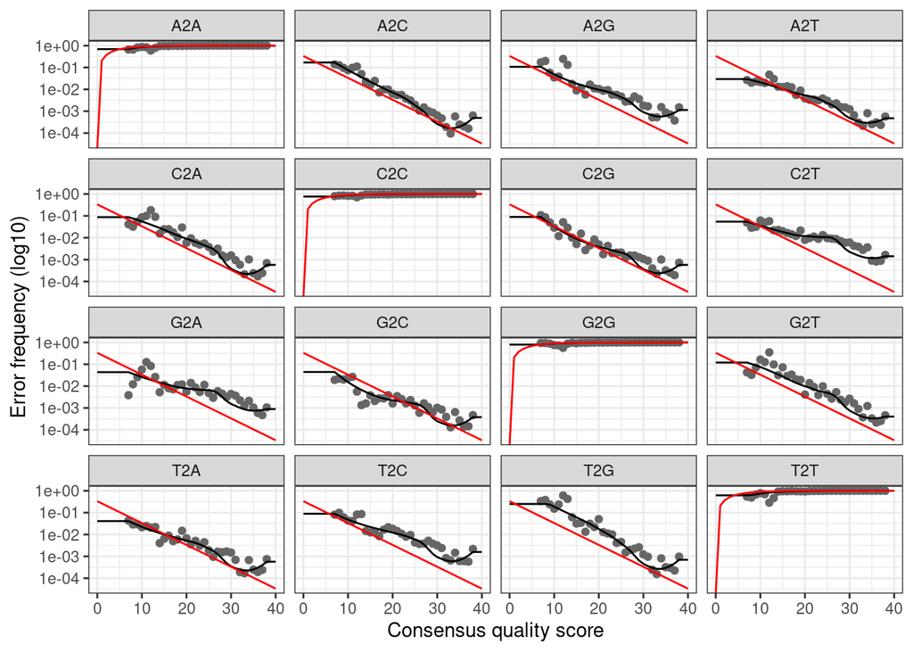

```r
plotErrors(errF, nominalQ=TRUE)
```

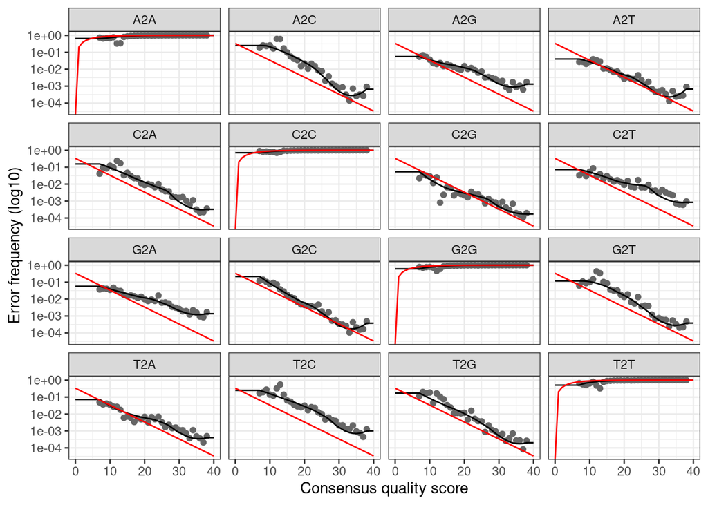

```r
plotErrors(errR, nominalQ=TRUE)
```

## Dereplication

```r
derepFs <- derepFastq(filtFs, verbose=TRUE)
```

```
#> Dereplicating sequence entries in Fastq file: ~/Escritorio/data_micro4all//cutadapt/filtered/L1-1_S102_R1_001.fastq
#> Encountered 14955 unique sequences from 57666 total sequences read.
#> Dereplicating sequence entries in Fastq file: ~/Escritorio/data_micro4all//cutadapt/filtered/L1-2_S112_R1_001.fastq
#> Encountered 12451 unique sequences from 57913 total sequences read.
#> Dereplicating sequence entries in Fastq file: ~/Escritorio/data_micro4all//cutadapt/filtered/L1-3_S121_R1_001.fastq
#> Encountered 13240 unique sequences from 64026 total sequences read.
#> Dereplicating sequence entries in Fastq file: ~/Escritorio/data_micro4all//cutadapt/filtered/L1-4_S130_R1_001.fastq
#> Encountered 13040 unique sequences from 65335 total sequences read.
#> Dereplicating sequence entries in Fastq file: ~/Escritorio/data_micro4all//cutadapt/filtered/L1-5_S138_R1_001.fastq
#> Encountered 19006 unique sequences from 88545 total sequences read.
#> Dereplicating sequence entries in Fastq file: ~/Escritorio/data_micro4all//cutadapt/filtered/L1-6_S145_R1_001.fastq
#> Encountered 14338 unique sequences from 66418 total sequences read.
#> Dereplicating sequence entries in Fastq file: ~/Escritorio/data_micro4all//cutadapt/filtered/L1-7_S152_R1_001.fastq
#> Encountered 14797 unique sequences from 63288 total sequences read.
#> Dereplicating sequence entries in Fastq file: ~/Escritorio/data_micro4all//cutadapt/filtered/L1-8_S159_R1_001.fastq
#> Encountered 16896 unique sequences from 65449 total sequences read.
#> Dereplicating sequence entries in Fastq file: ~/Escritorio/data_micro4all//cutadapt/filtered/L2-1_S139_R1_001.fastq
#> Encountered 12786 unique sequences from 61518 total sequences read.
#> Dereplicating sequence entries in Fastq file: ~/Escritorio/data_micro4all//cutadapt/filtered/L2-2_S146_R1_001.fastq
#> Encountered 16290 unique sequences from 70501 total sequences read.
#> Dereplicating sequence entries in Fastq file: ~/Escritorio/data_micro4all//cutadapt/filtered/L2-3_S153_R1_001.fastq
#> Encountered 12172 unique sequences from 61845 total sequences read.
#> Dereplicating sequence entries in Fastq file: ~/Escritorio/data_micro4all//cutadapt/filtered/L2-4_S160_R1_001.fastq
#> Encountered 16841 unique sequences from 71564 total sequences read.
#> Dereplicating sequence entries in Fastq file: ~/Escritorio/data_micro4all//cutadapt/filtered/L2-5_S104_R1_001.fastq
#> Encountered 14861 unique sequences from 60018 total sequences read.
#> Dereplicating sequence entries in Fastq file: ~/Escritorio/data_micro4all//cutadapt/filtered/L2-6_S114_R1_001.fastq
#> Encountered 16359 unique sequences from 69254 total sequences read.
#> Dereplicating sequence entries in Fastq file: ~/Escritorio/data_micro4all//cutadapt/filtered/L2-7_S123_R1_001.fastq
#> Encountered 15654 unique sequences from 66374 total sequences read.
#> Dereplicating sequence entries in Fastq file: ~/Escritorio/data_micro4all//cutadapt/filtered/L2-8_S132_R1_001.fastq
#> Encountered 13111 unique sequences from 53394 total sequences read.
#> Dereplicating sequence entries in Fastq file: ~/Escritorio/data_micro4all//cutadapt/filtered/L3-1_S136_R1_001.fastq
#> Encountered 14555 unique sequences from 69539 total sequences read.
#> Dereplicating sequence entries in Fastq file: ~/Escritorio/data_micro4all//cutadapt/filtered/L3-2_S143_R1_001.fastq
#> Encountered 11876 unique sequences from 55191 total sequences read.
#> Dereplicating sequence entries in Fastq file: ~/Escritorio/data_micro4all//cutadapt/filtered/L3-3_S150_R1_001.fastq
#> Encountered 13212 unique sequences from 54362 total sequences read.
#> Dereplicating sequence entries in Fastq file: ~/Escritorio/data_micro4all//cutadapt/filtered/L3-4_S157_R1_001.fastq
#> Encountered 12522 unique sequences from 53465 total sequences read.
#> Dereplicating sequence entries in Fastq file: ~/Escritorio/data_micro4all//cutadapt/filtered/L3-5_S101_R1_001.fastq
#> Encountered 12736 unique sequences from 55515 total sequences read.
#> Dereplicating sequence entries in Fastq file: ~/Escritorio/data_micro4all//cutadapt/filtered/L3-6_S111_R1_001.fastq
#> Encountered 11182 unique sequences from 62822 total sequences read.
#> Dereplicating sequence entries in Fastq file: ~/Escritorio/data_micro4all//cutadapt/filtered/L3-7_S120_R1_001.fastq
#> Encountered 12866 unique sequences from 66624 total sequences read.
#> Dereplicating sequence entries in Fastq file: ~/Escritorio/data_micro4all//cutadapt/filtered/L3-8_S129_R1_001.fastq
#> Encountered 9444 unique sequences from 49832 total sequences read.
#> Dereplicating sequence entries in Fastq file: ~/Escritorio/data_micro4all//cutadapt/filtered/MOCK-1_S169_R1_001.fastq
#> Encountered 7503 unique sequences from 86639 total sequences read.
#> Dereplicating sequence entries in Fastq file: ~/Escritorio/data_micro4all//cutadapt/filtered/MOCK-2_S176_R1_001.fastq
#> Encountered 7816 unique sequences from 90427 total sequences read.
#> Dereplicating sequence entries in Fastq file: ~/Escritorio/data_micro4all//cutadapt/filtered/MOCK-3_S183_R1_001.fastq
#> Encountered 9425 unique sequences from 103096 total sequences read.
```

```r
derepRs <- derepFastq(filtRs, verbose=TRUE)
```

```
#> Dereplicating sequence entries in Fastq file: ~/Escritorio/data_micro4all//cutadapt/filtered/L1-1_S102_R2_001.fastq
#> Encountered 15877 unique sequences from 57666 total sequences read.
#> Dereplicating sequence entries in Fastq file: ~/Escritorio/data_micro4all//cutadapt/filtered/L1-2_S112_R2_001.fastq
#> Encountered 9710 unique sequences from 57913 total sequences read.
#> Dereplicating sequence entries in Fastq file: ~/Escritorio/data_micro4all//cutadapt/filtered/L1-3_S121_R2_001.fastq
#> Encountered 11019 unique sequences from 64026 total sequences read.
#> Dereplicating sequence entries in Fastq file: ~/Escritorio/data_micro4all//cutadapt/filtered/L1-4_S130_R2_001.fastq
#> Encountered 11926 unique sequences from 65335 total sequences read.
#> Dereplicating sequence entries in Fastq file: ~/Escritorio/data_micro4all//cutadapt/filtered/L1-5_S138_R2_001.fastq
#> Encountered 16560 unique sequences from 88545 total sequences read.
#> Dereplicating sequence entries in Fastq file: ~/Escritorio/data_micro4all//cutadapt/filtered/L1-6_S145_R2_001.fastq
#> Encountered 12510 unique sequences from 66418 total sequences read.
#> Dereplicating sequence entries in Fastq file: ~/Escritorio/data_micro4all//cutadapt/filtered/L1-7_S152_R2_001.fastq
#> Encountered 11428 unique sequences from 63288 total sequences read.
#> Dereplicating sequence entries in Fastq file: ~/Escritorio/data_micro4all//cutadapt/filtered/L1-8_S159_R2_001.fastq
#> Encountered 14517 unique sequences from 65449 total sequences read.
#> Dereplicating sequence entries in Fastq file: ~/Escritorio/data_micro4all//cutadapt/filtered/L2-1_S139_R2_001.fastq
#> Encountered 10567 unique sequences from 61518 total sequences read.
#> Dereplicating sequence entries in Fastq file: ~/Escritorio/data_micro4all//cutadapt/filtered/L2-2_S146_R2_001.fastq
#> Encountered 12191 unique sequences from 70501 total sequences read.
#> Dereplicating sequence entries in Fastq file: ~/Escritorio/data_micro4all//cutadapt/filtered/L2-3_S153_R2_001.fastq
#> Encountered 9038 unique sequences from 61845 total sequences read.
#> Dereplicating sequence entries in Fastq file: ~/Escritorio/data_micro4all//cutadapt/filtered/L2-4_S160_R2_001.fastq
#> Encountered 13963 unique sequences from 71564 total sequences read.
#> Dereplicating sequence entries in Fastq file: ~/Escritorio/data_micro4all//cutadapt/filtered/L2-5_S104_R2_001.fastq
#> Encountered 12290 unique sequences from 60018 total sequences read.
#> Dereplicating sequence entries in Fastq file: ~/Escritorio/data_micro4all//cutadapt/filtered/L2-6_S114_R2_001.fastq
#> Encountered 13584 unique sequences from 69254 total sequences read.
#> Dereplicating sequence entries in Fastq file: ~/Escritorio/data_micro4all//cutadapt/filtered/L2-7_S123_R2_001.fastq
#> Encountered 13465 unique sequences from 66374 total sequences read.
#> Dereplicating sequence entries in Fastq file: ~/Escritorio/data_micro4all//cutadapt/filtered/L2-8_S132_R2_001.fastq
#> Encountered 11822 unique sequences from 53394 total sequences read.
#> Dereplicating sequence entries in Fastq file: ~/Escritorio/data_micro4all//cutadapt/filtered/L3-1_S136_R2_001.fastq
#> Encountered 12958 unique sequences from 69539 total sequences read.
#> Dereplicating sequence entries in Fastq file: ~/Escritorio/data_micro4all//cutadapt/filtered/L3-2_S143_R2_001.fastq
#> Encountered 10719 unique sequences from 55191 total sequences read.
#> Dereplicating sequence entries in Fastq file: ~/Escritorio/data_micro4all//cutadapt/filtered/L3-3_S150_R2_001.fastq
#> Encountered 10263 unique sequences from 54362 total sequences read.
#> Dereplicating sequence entries in Fastq file: ~/Escritorio/data_micro4all//cutadapt/filtered/L3-4_S157_R2_001.fastq
#> Encountered 11177 unique sequences from 53465 total sequences read.
#> Dereplicating sequence entries in Fastq file: ~/Escritorio/data_micro4all//cutadapt/filtered/L3-5_S101_R2_001.fastq
#> Encountered 10466 unique sequences from 55515 total sequences read.
#> Dereplicating sequence entries in Fastq file: ~/Escritorio/data_micro4all//cutadapt/filtered/L3-6_S111_R2_001.fastq
#> Encountered 10088 unique sequences from 62822 total sequences read.
#> Dereplicating sequence entries in Fastq file: ~/Escritorio/data_micro4all//cutadapt/filtered/L3-7_S120_R2_001.fastq
#> Encountered 12561 unique sequences from 66624 total sequences read.
#> Dereplicating sequence entries in Fastq file: ~/Escritorio/data_micro4all//cutadapt/filtered/L3-8_S129_R2_001.fastq
#> Encountered 9159 unique sequences from 49832 total sequences read.
#> Dereplicating sequence entries in Fastq file: ~/Escritorio/data_micro4all//cutadapt/filtered/MOCK-1_S169_R2_001.fastq
#> Encountered 6990 unique sequences from 86639 total sequences read.
#> Dereplicating sequence entries in Fastq file: ~/Escritorio/data_micro4all//cutadapt/filtered/MOCK-2_S176_R2_001.fastq
#> Encountered 6925 unique sequences from 90427 total sequences read.
#> Dereplicating sequence entries in Fastq file: ~/Escritorio/data_micro4all//cutadapt/filtered/MOCK-3_S183_R2_001.fastq
#> Encountered 8145 unique sequences from 103096 total sequences read.
```

```r
# Name the derep-class objects by the sample names
names(derepFs) <- sample.names
names(derepRs) <- sample.names
```

## Sample inference

```r
dadaFs <- dada(derepFs, err=errF, multithread=TRUE)
```

```
#> Sample 1 - 57666 reads in 14955 unique sequences.
#> Sample 2 - 57913 reads in 12451 unique sequences.
#> Sample 3 - 64026 reads in 13240 unique sequences.
#> Sample 4 - 65335 reads in 13040 unique sequences.
#> Sample 5 - 88545 reads in 19006 unique sequences.
#> Sample 6 - 66418 reads in 14338 unique sequences.
#> Sample 7 - 63288 reads in 14797 unique sequences.
#> Sample 8 - 65449 reads in 16896 unique sequences.
#> Sample 9 - 61518 reads in 12786 unique sequences.
#> Sample 10 - 70501 reads in 16290 unique sequences.
#> Sample 11 - 61845 reads in 12172 unique sequences.
#> Sample 12 - 71564 reads in 16841 unique sequences.
#> Sample 13 - 60018 reads in 14861 unique sequences.
#> Sample 14 - 69254 reads in 16359 unique sequences.
#> Sample 15 - 66374 reads in 15654 unique sequences.
#> Sample 16 - 53394 reads in 13111 unique sequences.
#> Sample 17 - 69539 reads in 14555 unique sequences.
#> Sample 18 - 55191 reads in 11876 unique sequences.
#> Sample 19 - 54362 reads in 13212 unique sequences.
#> Sample 20 - 53465 reads in 12522 unique sequences.
#> Sample 21 - 55515 reads in 12736 unique sequences.
#> Sample 22 - 62822 reads in 11182 unique sequences.
#> Sample 23 - 66624 reads in 12866 unique sequences.
#> Sample 24 - 49832 reads in 9444 unique sequences.
#> Sample 25 - 86639 reads in 7503 unique sequences.
#> Sample 26 - 90427 reads in 7816 unique sequences.
#> Sample 27 - 103096 reads in 9425 unique sequences.
```

```r
dadaRs <- dada(derepRs, err=errR, multithread=TRUE)
```

```
#> Sample 1 - 57666 reads in 15877 unique sequences.
#> Sample 2 - 57913 reads in 9710 unique sequences.
#> Sample 3 - 64026 reads in 11019 unique sequences.
#> Sample 4 - 65335 reads in 11926 unique sequences.
#> Sample 5 - 88545 reads in 16560 unique sequences.
#> Sample 6 - 66418 reads in 12510 unique sequences.
#> Sample 7 - 63288 reads in 11428 unique sequences.
#> Sample 8 - 65449 reads in 14517 unique sequences.
#> Sample 9 - 61518 reads in 10567 unique sequences.
#> Sample 10 - 70501 reads in 12191 unique sequences.
#> Sample 11 - 61845 reads in 9038 unique sequences.
#> Sample 12 - 71564 reads in 13963 unique sequences.
#> Sample 13 - 60018 reads in 12290 unique sequences.
#> Sample 14 - 69254 reads in 13584 unique sequences.
#> Sample 15 - 66374 reads in 13465 unique sequences.
#> Sample 16 - 53394 reads in 11822 unique sequences.
#> Sample 17 - 69539 reads in 12958 unique sequences.
#> Sample 18 - 55191 reads in 10719 unique sequences.
#> Sample 19 - 54362 reads in 10263 unique sequences.
#> Sample 20 - 53465 reads in 11177 unique sequences.
#> Sample 21 - 55515 reads in 10466 unique sequences.
#> Sample 22 - 62822 reads in 10088 unique sequences.
#> Sample 23 - 66624 reads in 12561 unique sequences.
#> Sample 24 - 49832 reads in 9159 unique sequences.
#> Sample 25 - 86639 reads in 6990 unique sequences.
#> Sample 26 - 90427 reads in 6925 unique sequences.
#> Sample 27 - 103096 reads in 8145 unique sequences.
```

```r
dadaFs[[1]]
```

```
#> dada-class: object describing DADA2 denoising results
#> 765 sequence variants were inferred from 14955 input unique sequences.
#> Key parameters: OMEGA_A = 1e-40, OMEGA_C = 1e-40, BAND_SIZE = 16
```

## Merge paired-end reads

```r
mergers <- mergePairs(dadaFs, derepFs, dadaRs, derepRs, verbose=TRUE)
```

```
#> 53900 paired-reads (in 678 unique pairings) successfully merged out of 55728 (in 1223 pairings) input.
```

```
#> 55352 paired-reads (in 442 unique pairings) successfully merged out of 56556 (in 879 pairings) input.
```

```
#> 61930 paired-reads (in 411 unique pairings) successfully merged out of 62917 (in 772 pairings) input.
```

```
#> 63260 paired-reads (in 415 unique pairings) successfully merged out of 64286 (in 773 pairings) input.
```

```
#> 85038 paired-reads (in 816 unique pairings) successfully merged out of 86635 (in 1384 pairings) input.
```

```
#> 63453 paired-reads (in 539 unique pairings) successfully merged out of 64797 (in 1029 pairings) input.
```

```
#> 60611 paired-reads (in 484 unique pairings) successfully merged out of 61941 (in 951 pairings) input.
```

```
#> 61760 paired-reads (in 706 unique pairings) successfully merged out of 63462 (in 1299 pairings) input.
```

```
#> 59443 paired-reads (in 543 unique pairings) successfully merged out of 60379 (in 850 pairings) input.
```

```
#> 68043 paired-reads (in 552 unique pairings) successfully merged out of 69170 (in 938 pairings) input.
```

```
#> 59904 paired-reads (in 385 unique pairings) successfully merged out of 60866 (in 679 pairings) input.
```

```
#> 68749 paired-reads (in 639 unique pairings) successfully merged out of 69992 (in 1072 pairings) input.
```

```
#> 57070 paired-reads (in 521 unique pairings) successfully merged out of 58668 (in 1120 pairings) input.
```

```
#> 66246 paired-reads (in 692 unique pairings) successfully merged out of 67546 (in 1192 pairings) input.
```

```
#> 63487 paired-reads (in 687 unique pairings) successfully merged out of 64912 (in 1083 pairings) input.
```

```
#> 50518 paired-reads (in 599 unique pairings) successfully merged out of 51874 (in 1006 pairings) input.
```

```
#> 67341 paired-reads (in 605 unique pairings) successfully merged out of 68351 (in 971 pairings) input.
```

```
#> 53496 paired-reads (in 388 unique pairings) successfully merged out of 54300 (in 649 pairings) input.
```

```
#> 52289 paired-reads (in 656 unique pairings) successfully merged out of 53118 (in 937 pairings) input.
```

```
#> 51550 paired-reads (in 581 unique pairings) successfully merged out of 52326 (in 872 pairings) input.
```

```
#> 53447 paired-reads (in 498 unique pairings) successfully merged out of 54414 (in 866 pairings) input.
```

```
#> 61523 paired-reads (in 427 unique pairings) successfully merged out of 62199 (in 650 pairings) input.
```

```
#> 64831 paired-reads (in 441 unique pairings) successfully merged out of 65724 (in 755 pairings) input.
```

```
#> 48744 paired-reads (in 311 unique pairings) successfully merged out of 49287 (in 495 pairings) input.
```

```
#> 86473 paired-reads (in 52 unique pairings) successfully merged out of 86546 (in 81 pairings) input.
```

```
#> 90229 paired-reads (in 70 unique pairings) successfully merged out of 90305 (in 97 pairings) input.
```

```
#> 102717 paired-reads (in 101 unique pairings) successfully merged out of 102889 (in 141 pairings) input.
```

```r
# Inspect the merger data.frame from the first sample
head(mergers[[1]])
```

```
#>                                                                                                                                                                                                                                                                                                          …
#> 1   TGGGGAATATTGCACAATGGGCGAAAGCCTGATGCAGCGACGCCGCGTGAGGGATGACGG…
#> 2 TGGGGAATATTGCGCAATGGGCGAAAGCCTGACGCAGCGACGCCGCGTGAGGGATGACGG…
#> 3   TGGGGAATATTGCACAATGGGCGAAAGCCTGATGCAGCGACGCCGCGTGAGGGATGACGG…
#> 4   TGGGGAATATTGCGCAATGGGCGAAAGCCTGACGCAGCGACGCCGCGTGAGGGATGACGG…
#> 5      TGGGGAATCTTGGACAATGGGCGAAAGCCCGATCCAGCAATATCGCGTGAGTGAAGAAGG…
#> 6   TGGGGAATATTGCGCAATGGGCGGAAGCCTGACGCAGCGACGCCGCGTGGGGGATGACGG…
#>   abundance forward reverse nmatch nmismatch nindel prefer accept
#> 1      6642       1       2     77         0      0      1   TRUE
#> 2      5293       2       1     75         0      0      2   TRUE
#> 3      3548       3       3     77         0      0      1   TRUE
#> 4      2098       4       1     77         0      0      2   TRUE
#> 5      1819       6       4     80         0      0      1   TRUE
#> 6      1797       5       5     77         0      0      1   TRUE
```

## Construct sequence table

```r
seqtab <- makeSequenceTable(mergers)
dim(seqtab) ##
```

```
#> [1]   27 5739
```

## Remove chimeras

```r
seqtab.nochim <- removeBimeraDenovo(seqtab, method="consensus", multithread=TRUE, verbose=TRUE)
```

```
#> Identified 1221 bimeras out of 5739 input sequences.
```

```r
dim(seqtab.nochim)
```

```
#> [1]   27 4518
```

## Inspect ASV length and abundance

```r
table(nchar(getSequences(seqtab.nochim)))  #Number of ASV of each length
```

```
#>
#> 283 300 304 314 316 321 327 338 339 356 359 361 364 366 369 370 371 373 376 380 382 384 385 386 390 391 396
#>   1   1   1   1   1   1   1   1   1   1   1   1   2   1   1   1   1   1   1   1   2   2   5   8   1   1   4
#> 397 398 399 400 401 402 403 404 405 406 407 408 409 410 411 412 413 414 415 416 417 418 419 420 421 422 423
#>   2   1   1   4  45 918 289 187 154  18 364  74  39  20  21   2  11   4   4  52  16  18  28  25 205 513  36
#> 424 425 426 427 428 429 430 432 441 464
#>  29  50 240 891 191  13   2   5   1   1
```

This is useful, but we also want to know the abundance of sequences for each length. Let’s calculate it and make a plot

```r
reads.per.seqlen <- tapply(colSums(seqtab.nochim), factor(nchar(getSequences(seqtab.nochim))), sum) #number of sequences for each length
reads.per.seqlen
```

```
#>    283    300    304    314    316    321    327    338    339    356    359    361    364    366    369
#>      2      7      4      4      2      2      4      2      2      2      2      4     48      2      4
#>    370    371    373    376    380    382    384    385    386    390    391    396    397    398    399
#>      2      2      6      3      4  35418      8     34   1008      2      7     12     13      2      3
#>    400    401    402    403    404    405    406    407    408    409    410    411    412    413    414
#>    611    439 126472  95838 266118   3837    938 566138 105352  55415   1497   1255   4358    171   2305
#>    415    416    417    418    419    420    421    422    423    424    425    426    427    428    429
#>     80   2775    123    595   5506    880  11417  28397    255    436   3951  11852 357556  13032    111
#>    430    432    441    464
#>      5    202      3      4
```

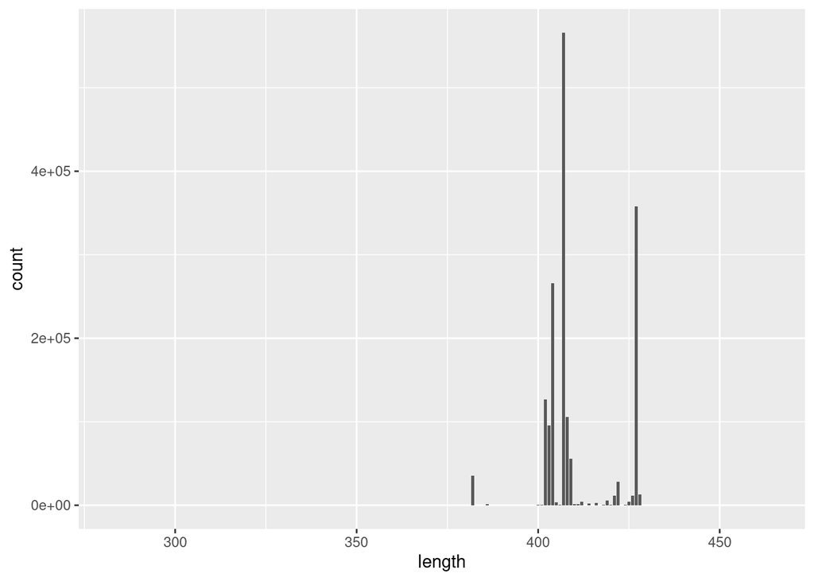

```r
## Plot length distribution
table_reads_seqlen <- data.frame(length=as.numeric(names(reads.per.seqlen)), count=reads.per.seqlen)

ggplot(data=table_reads_seqlen, aes(x=length, y=count)) + geom_col()
```

According to previous information, we will choose the interval ranging from 402 to 428 pb

```r
seqtab.nochim <- seqtab.nochim[,nchar(colnames(seqtab.nochim)) %in% seq(402,428)]
```

## Check number of reads

At this point, it is important to check how many sequences we have lost in each step. Apart from filtering, not other step should have led to a substantial decreased in sequence number.

```r
getN <- function(x) sum(getUniques(x))
track <- cbind(out, sapply(dadaFs, getN), sapply(dadaRs, getN), sapply(mergers, getN), rowSums(seqtab.nochim))
# If processing a single sample, remove the sapply calls: e.g. replace sapply(dadaFs, getN) with getN(dadaFs)
colnames(track) <- c("input", "filtered", "denoisedF", "denoisedR", "merged", "nonchim")
rownames(track) <- sample.names


#Let's apply a mutate to get percentage, making it easier to analyze.
track <- track %>%as.data.frame() %>% mutate(Perc.input=filtered*100/input,
                                             Perc.denoisedF= denoisedF*100/filtered,
                                             Perc.denoisedR= denoisedR*100/filtered,
                                             Perc.merged= merged*100/filtered,
                                             Perc.nonchim= nonchim*100/merged)

track
```

```
#>         input filtered denoisedF denoisedR merged nonchim Perc.input Perc.denoisedF Perc.denoisedR
#> L1-1    78916    57666     56236     56748  53900   51882   73.07263       97.52020       98.40807
#> L1-2    75708    57913     56927     57247  55352   53948   76.49522       98.29745       98.85000
#> L1-3    83818    64026     63178     63563  61930   60052   76.38693       98.67554       99.27686
#> L1-4    86047    65335     64570     64862  63260   60782   75.92943       98.82911       99.27604
#> L1-5   113411    88545     87120     87642  85038   80573   78.07444       98.39065       98.98018
#> L1-6    87404    66418     65229     65670  63453   61858   75.98966       98.20982       98.87380
#> L1-7    81538    63288     62311     62652  60611   58524   77.61780       98.45626       98.99507
#> L1-8    84651    65449     63902     64652  61760   59372   77.31628       97.63633       98.78226
#> L2-1    79038    61518     60715     60952  59443   56129   77.83345       98.69469       99.07994
#> L2-2    91229    70501     69428     70001  68043   65531   77.27915       98.47804       99.29079
#> L2-3    79363    61845     61071     61433  59904   58637   77.92674       98.74848       99.33382
#> L2-4    91598    71564     70388     70925  68749   66349   78.12834       98.35672       99.10709
#> L2-5    76893    60018     59018     59435  57070   54427   78.05392       98.33383       99.02862
#> L2-6    88718    69254     67956     68553  66246   63931   78.06082       98.12574       98.98778
#> L2-7    84940    66374     65270     65719  63487   60551   78.14222       98.33670       99.01317
#> L2-8    70376    53394     52316     52646  50518   48306   75.86961       97.98105       98.59909
#> L3-1    88860    69539     68664     69025  67341   63898   78.25681       98.74171       99.26085
#> L3-2    72141    55191     54485     54824  53496   51061   76.50435       98.72081       99.33504
#> L3-3    69064    54362     53434     53762  52289   49937   78.71250       98.29293       98.89629
#> L3-4    69103    53465     52594     52961  51550   49337   77.37001       98.37090       99.05733
#> L3-5    70198    55515     54686     55047  53447   51695   79.08345       98.50671       99.15698
#> L3-6    80416    62822     62360     62544  61523   57449   78.12127       99.26459       99.55748
#> L3-7    84050    66624     65988     66191  64831   62442   79.26710       99.04539       99.35008
#> L3-8    65732    49832     49429     49551  48744   45423   75.81087       99.19128       99.43611
#> MOCK-1 104782    86639     86565     86586  86473   85385   82.68500       99.91459       99.93883
#> MOCK-2 108997    90427     90339     90357  90229   88829   82.96283       99.90268       99.92259
#> MOCK-3 124752   103096    102989    102960 102717  100241   82.64076       99.89621       99.86808
#>        Perc.merged Perc.nonchim
#> L1-1      93.46929     96.25603
#> L1-2      95.57785     97.46351
#> L1-3      96.72633     96.96754
#> L1-4      96.82406     96.08283
#> L1-5      96.03930     94.74941
#> L1-6      95.53585     97.48633
#> L1-7      95.77013     96.55673
#> L1-8      94.36355     96.13342
#> L2-1      96.62700     94.42491
#> L2-2      96.51352     96.30822
#> L2-3      96.86151     97.88495
#> L2-4      96.06646     96.50904
#> L2-5      95.08814     95.36885
#> L2-6      95.65657     96.50545
#> L2-7      95.65041     95.37543
#> L2-8      94.61363     95.62136
#> L3-1      96.83918     94.88722
#> L3-2      96.92885     95.44826
#> L3-3      96.18667     95.50192
#> L3-4      96.41822     95.70708
#> L3-5      96.27488     96.72199
#> L3-6      97.93225     93.37809
#> L3-7      97.30878     96.31503
#> L3-8      97.81666     93.18685
#> MOCK-1    99.80840     98.74180
#> MOCK-2    99.78104     98.44839
#> MOCK-3    99.63238     97.58949
```

Everything is as expected, so let’s keep on with classification!

## Taxonomy classification with RDP

```r
taxa_rdp <- assignTaxonomy(seqtab.nochim, "~/Escritorio/data_micro4all/rdp_train_set_18_H.fa", multithread=TRUE)
```

## ASV TABLE

We will produce a raw ASV table that can be saved as `.txt`. This allows us to manipulate the data manually if needed, as well as saving a raw data before further steps are performed.

```r
ASV <- seqtab.nochim
ASVt <- t(ASV)

## SUBSTITUTE 'NA' WITH 'UNCLASSIFIED'and remove species column
taxa_rdp_na <- apply(taxa_rdp,2, tidyr::replace_na, "unclassified")[,-7]

##Create names for each ASV: if there are 1000 ASVs, call them from ASV0001 to ASV1000
number.digit<- nchar(as.integer(nrow(ASVt)))
names <- paste0("ASV%0", number.digit, "d") #As many 0 as digits
ASV_names<- sprintf(names, 1:nrow(ASVt))

## CREATE AND SAVE ASV TABLE
ASV_table_classified_raw<- cbind(as.data.frame(taxa_rdp_na,stringsAsFactors = FALSE),as.data.frame(ASV_names, stringsAsFactors = FALSE),as.data.frame(ASVt,stringsAsFactors = FALSE))

##Make rownames a new column, in order to keep sequences during the filtering process
ASV_seqs <- rownames(ASV_table_classified_raw)
rownames(ASV_table_classified_raw) <- NULL
ASV_table_classified_raw <- cbind(ASV_seqs, ASV_table_classified_raw)
```

## MOCK community

In order to filter out sporious ASV, we always introduce in our sequencing three samples of a commercial MOCK community (ZymoBIOMICS Microbial Community Standard II (Log Distribution), ZYMORESEARCH, CA, USA). Because we already know its composition, we can check if there is any ASV identified by the sequencing process that is not a real member of the community. Once identified, we calculate the percentage of sequences it represents. We make the assumption that ASVs that represent less than this percentage should be discarded from our data. In order to automate this analysis, `micro4all` implements a function called `MockCommunity`. Let’s see how it works:

```r
#### REMOVE MOCK COMMUNITY ####

##GET TABLE FILERED ACCORDING TO MOCK
ASV_filtered_sorted<-MockCommunity(ASV_table_classified_raw, mock_composition, ASV_column = "ASV_names") #mock_composition is a data frame included as data in this package. See documentation for details.
```

```
#> ASV0797 does not belong to the MOCK community. It representes a  0.032064  perc. of the sequences
#>  and it classifies as Limosilactobacillus
#>  Do you want to use this ASV to calculate the percentage? [answer yes or no]ASV0002 does not belong to the MOCK community. It representes a  0.003644  perc. of the sequences
#>  and it classifies as Streptomyces
#>  Do you want to use this ASV to calculate the percentage? [answer yes or no]You made a decision! ASV0002 which classifies as Streptomyces
#>  and represents a 0.003644 perc. of the sequences, was used to calculate the percentage
```

`MockCommunity` makes a question to user before making the decision. Why? Sometimes, like in the example above, an ASV could be classified with a different name, still being the same genera. In this example, the first ASV which is not detected in the MOCK community composition table, is *Limosilactobacillus*. However, we can see that it represents a high percentage of sequences. This is probably a *bacillus* from MOCK samples. Because of that, we decide to choose the second option.

Once the percentage is applied, we can remove sequences coming from chloroplast or mitochondria.

```r
#### REMOVE CHLOROPLASTS AND MITOCHONDRIA ####
ASV_final_table<-ASV_filtered_sorted[(which(ASV_filtered_sorted$Genus!="Streptophyta"
                                            & ASV_filtered_sorted$Genus!="Chlorophyta"
                                            &ASV_filtered_sorted$Genus!="Bacillariophyta"
                                            &ASV_filtered_sorted$Family!="Streptophyta"
                                            & ASV_filtered_sorted$Family!="Chlorophyta"
                                            &ASV_filtered_sorted$Family!="Bacillariophyta"
                                            & ASV_filtered_sorted$Family!="Mitochondria"
                                            & ASV_filtered_sorted$Class!="Chloroplast"
                                            & ASV_filtered_sorted$Order!="Chloroplast"
                                            & ASV_filtered_sorted$Kingdom!="Eukaryota"
                                            & ASV_filtered_sorted$Kingdom!="unclassified")),]





##After this, I checked the presence of Cyanobacteria/Chloroplast   at phylum level.
#I only had two ASVs classified as Cyanobacteria/Chloroplast at phylum level which were not classified at deeper levels,
#so I removed them, as follow:
#

ASV_final_table<-ASV_final_table[(which(ASV_final_table$Phylum!="Cyanobacteria/Chloroplast"
)),]
```

# DIVERSITY ANALYSIS

We almost have all components to perform a full diversity analysis. For this purpose, we need a phyloseq object. Before that, we should produce a phylogenetic tree, which allows us to use *UniFrac* and *WeightedUnifrac* distances later on. We will use programs as MAFFT^5 and FastTreeMP^6.

```r
## GET THE FASTA FILE ##
library(seqinr)
ASVseqs_MOCK <- as.list(ASV_final_table$ASV_seqs)
write.fasta(ASVseqs_MOCK, names=ASV_final_table$ASV_names, file.out="ASV_tree.fas", open = "w", nbchar =1000 , as.string = FALSE)

##Get the alignment ##
mafft <- "/usr/bin/mafft"     #path to program

system2(mafft, args="--version")
system2(mafft, args=c("--auto", "ASV_tree.fas>", "alignment"))

## Get the tree ##
FastTreeMP <- "/home/programs/FastTreeMP/FastTreeMP"

system2(FastTreeMP, args="--version" )
system2(FastTreeMP, args = c("-gamma", "-nt", "-gtr", "-spr",4 ,"-mlacc", 2,  "-slownni", "<alignment>", "tree"))# Run FastTreeMP

##Introduce phylogenetic tree

tree <-  phyloseq::read_tree("tree")
```

## Create phyloseq

We will put all the information we have (classification, abundance, metadata, ASV sequences and phylogenetic tree) in one object thanks to `phyloseq`^7. We get metadata table from `micro4all`package, as it is stored as data, but it simply consist on a data frame with sample names and location. Later on, this will allow us to group samples by location.

```r
##Load packages
library(phyloseq); packageVersion("phyloseq")
```

```
#> [1] '1.36.0'
```

```r
library(Biostrings); packageVersion("Biostrings")
```

```
#> [1] '2.60.2'
```

```r
library(GUniFrac); packageVersion("GUniFrac")
```

```
#> [1] '1.3'
```

```r
library(phangorn); packageVersion("phangorn")
```

```
#> [1] '2.7.1'
```

```r
library(vegan); packageVersion("vegan")
```

```
#> [1] '2.5.7'
```

```r
library(pheatmap); packageVersion("pheatmap")
```

```
#> [1] '1.0.12'
```

```r
library(colorspace); packageVersion("colorspace")
```

```
#> [1] '2.0.2'
```

```r
####CREATE PHYLOSEQ OBJECT FROM TABLES
##Get tax, otu and sequences
tax <- ASV_final_table[,2:8] #Tax

OTU <-  ASV_final_table[,9:ncol(ASV_final_table)] #ASV
colnames(OTU) <- str_replace_all(colnames(OTU),"-", "_")

dna<-Biostrings::DNAStringSet(ASV_final_table$ASV_seqs) #Sequences
names(dna)<- ASV_final_table$ASV_names

##ADD ASV NAMES
row.names(tax)<-ASV_final_table$ASV_names
row.names(OTU)<-ASV_final_table$ASV_names
#Check rownames are equal
identical(rownames(OTU), rownames(tax))
```

```
#> [1] TRUE
```

```r
##CONVERT TO PHYLOSEQ FORMART
metadata.micro <-micro4all::metadata
metadata.micro$samples <- str_replace_all(metadata.micro$samples,"-", "_")
rownames(metadata.micro) <- str_replace_all(rownames(metadata.micro),"-", "_")
as.data.frame(gsub("-",replacement = ".", metadata.micro))
```

```
#>                                                                                                                                                                                                                                                                                gsub("-", replacement = ".…
#> 1                                                                                                                         c("L1_1", "L1_2", "L1_3", "L1_4", "L1_5", "L1_6", "L1_7", "L1_8", "L2_1", "L2_2", "L2_3", "L2_4", "L2_5", "L2_6", "L2_7", "L2_8", "L3_1", "L3_2", "L3_3", "L3_4", "L3_5", "L3_6…
#> 2 c("location1", "location1", "location1", "location1", "location1", "location1", "location1", "location1", "location2", "location2", "location2", "location2", "location2", "location2", "location2", "location2", "location3", "location3", "location3", "location3", "location3", "location3", "locati…
```

```r
phy_OTUtable<-otu_table(OTU, taxa_are_rows = T)
phy_taxonomy<-tax_table(as.matrix(tax))
phy_metadata<-sample_data(metadata.micro)

##Introduce phylogenetic tree
unrooted_tree<- tree
is.rooted(unrooted_tree)
```

```
#> [1] FALSE
```

```r
##Produce root
tree_root<-root(unrooted_tree, 1, resolve.root = T)
tree_root
```

```
#>
#> Phylogenetic tree with 1069 tips and 1068 internal nodes.
#>
#> Tip labels:
#>   ASV0021, ASV0042, ASV0093, ASV0099, ASV0334, ASV0524, ...
#> Node labels:
#>   Root, 0.911, 0.868, 0.893, 0.959, 0.769, ...
#>
#> Rooted; includes branch lengths.
```

```r
is.rooted(tree_root)
```

```
#> [1] TRUE
```

```r
##Add tree to phyloseq
location_phyloseq<-phyloseq(phy_OTUtable,phy_taxonomy,phy_metadata,dna,tree_root)
```

## $\alpha$ diversity

### Data preparation

First, we will produce a table with $\alpha$ diversity indexes. For this purpose, we will rarefy the data to the lowest sequence number. This is done in order to avoid an over estimation of diversity only because of a greater number of sequences.

Rarefaction curves should be produced first. This makes it easy to visualize if rarefaction process encountered a great loss of information or not. This plot represents number of ASV (richness) against number of sequences. Moreover, a vertical line will show the number of sequences where normalization occurred. If this line is found in the asymptote of every rarefaction curve, that means we are safe: although we would have more sequences for every sample, we would not have a significant greater number of ASV.

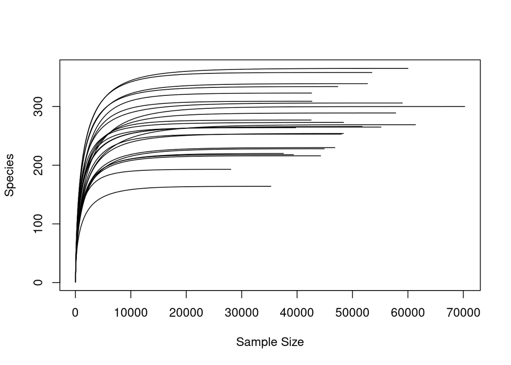

```r
ASV <- as.data.frame(t(otu_table(location_phyloseq)))
sample_names <- rownames(ASV)

#Generate rarefaction curves
rarecurve <- rarecurve(ASV, step = 100, label = F)
```

We will make some preparation for ggplot

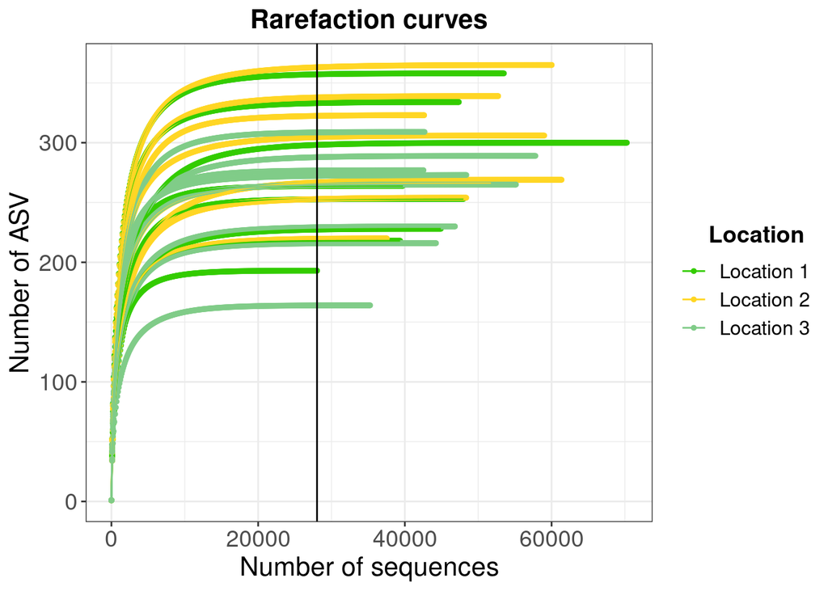

```r
#For each rarefaction curve, transform rarecurve output to a dataframe.
rarecurve_table <- lapply(rarecurve, function(x){
  b <- as.data.frame(x)
  b <- data.frame(ASV = b[,1], raw.read = rownames(b))
  b$raw.read <- as.numeric(gsub("N", "",  b$raw.read))
  return(b)
})

#Produce a column with sample names and put everything in one data frame
names(rarecurve_table) <- sample_names
rarecurve_table <- purrr::map_dfr(rarecurve_table, function(x){
  z <- data.frame(x)
  return(z)
}, .id = "Sample")


#To color lines according to group, let's create a new column
#Coloring
color <- NULL
for (i in (1:length(rarecurve_table$Sample))) {
  color <- rbind(color,metadata.micro$location[which(metadata.micro$samples==rarecurve_table$Sample[i])])##Change "Location" to variable of interest
}

#Bind this column
rarecurve_table_color <- cbind(rarecurve_table, color)
colnames(rarecurve_table_color) <- c(colnames(rarecurve_table), "Location")


## RARECURVE WITH GGPLOT ##
rareggplot<-ggplot(rarecurve_table_color, aes(x=raw.read, y=ASV, colour=Location, group=Sample)) + ### IMPORTANT TO GROUP BY SAMPLE
  theme_bw()+
  geom_point(aes(colour=Location), size=1)+
  geom_line(aes(colour=Location),size=0.5)+ #Change this for line thickness
  geom_vline(aes(xintercept = min(sample_sums(location_phyloseq))), lty=1, colour="black")+
  scale_fill_manual(values = c("location1"= "#33CC00", "location2"= "#ffd624", "location3"="#80CC88"))+
  scale_color_manual(values = c("location1"= "#33CC00","location2"= "#ffd624", "location3"="#80CC88"),
                     name="Location",
                     breaks=c("location1", "location2","location3"),
                     labels=c("Location 1","Location 2","Location 3"))+
  labs(title="Rarefaction curves", x="Number of sequences", y="Number of ASV")+
  guides(alpha="none")+
  theme(legend.key=element_blank(),
        legend.title.align = 0.85,
        legend.title = element_text(face="bold",size=14),
        axis.text = element_text(size=14),
        axis.title = element_text(size = 16),
        plot.title = element_text(hjust=0.5, face="bold", size=16),
        legend.text = element_text(size = 12))

rareggplot
```

As we can see, the rarefaction process took place in the asymptote of all samples.

For saving plots in your machine, an easy and versatile option is to use `ggsave` form `ggplot`. For publication, you can save it in .TIFF, but there are also other interesting formats. For example, .svg allows you to open the file in `PowerPoint` and easily modify it. If you have more knowledge of softwares as `Illustrator` you can save it in .eps

```r
#tiff
ggsave(filename = "rarefaction_curve.tiff", plot = rareggplot,device = tiff(),width = 18, height = 16, units = "cm", dpi = 800)

#svg
library(svglite)
ggsave(filename = "rarefaction_curve.svg", plot = rareggplot,device = svg())
#eps
postscript("curve_wito_RE.1.10.eps")
rareggplot
dev.off()  # Close the device
```

Let’s continue! Now, we will compute symbol(“alpha”) diversity indexes. First, let’s rarefied samples, as everything worked well.

```r
rarefaction <- rarefy_even_depth(location_phyloseq, sample.size = min(sample_sums(location_phyloseq)), rngseed = TRUE)
```

```
#> `set.seed(TRUE)` was used to initialize repeatable random subsampling.
```

```
#> Please record this for your records so others can reproduce.
```

```
#> Try `set.seed(TRUE); .Random.seed` for the full vector
```

```
#> ...
```

```r
#Get the seed and record it for reproducible analysis
.Random.seed[1]
```

```
#> [1] 10403
```

```r
##[1] 10403
```

```r
#Estimate alpha indixes and save it
alpha_diversity_rarefied <- estimate_richness(rarefaction,measures=c("InvSimpson", "Shannon", "Observed"))

## CALCULATE EVENNESS
tASV <- as.data.frame(t(otu_table(rarefaction)))

Evenness_index <- as.data.frame(alpha_diversity_rarefied$Shannon/log(specnumber(tASV)))
Evenness <- cbind(Evenness_index, rownames(alpha_diversity_rarefied))
colnames(Evenness) <- c("Evenness", "Samples")
```

In this step, it is worth mentioning that we have not used diversity estimates of richness. These estimates rely on singletons. However, `dada2` doesn’t produce singletons as ASV, they can only appear because of the merging process (being not a real singleton for a richness estimate to rely on). For more details, check [dada2 issue #92](https://github.com/benjjneb/dada2/issues/92).

```r
#Generate final table
alpha_diversity_table <- cbind(alpha_diversity_rarefied, Evenness$Evenness, metadata.micro)
colnames(alpha_diversity_table)<- c("Observed", "Shannon", "InvSimpson", "Evenness",colnames(metadata.micro))
```

We got the final table with the diversity indexes we want to study, but it is also interesting to produce a table ready for publication.

```r
#Select numeric columns and compute mean and SD
alpha_mean <- aggregate(alpha_diversity_table[,1:4], list(grouping=alpha_diversity_table$location), mean)%>% mutate_if(is.numeric, round, digits=2)
alpha_sd <- aggregate(alpha_diversity_table[,1:4], list(grouping=alpha_diversity_table$location), sd)%>% mutate_if(is.numeric, round, digits=2)

#Paste mean ± SD
mean_sd <- NULL
for (i in 2:5){
  mean_sd <- cbind(mean_sd,paste0(alpha_mean[,i], " +/- ", alpha_sd[,i]))}


#generate table and give it columns names
alpha_pub_table <- cbind(alpha_mean$grouping, mean_sd)
colnames(alpha_pub_table) <- c("Location","Observed", "Shannon", "InvSimpson", "Evenness")


as.data.frame(alpha_pub_table)
```

```
#>    Location         Observed       Shannon     InvSimpson      Evenness
#> 1 location1 266.62 +/- 56.63 3.74 +/- 0.35 15.17 +/- 6.59 0.67 +/- 0.04
#> 2 location2 289.12 +/- 47.42 3.99 +/- 0.36  23.22 +/- 7.2  0.7 +/- 0.05
#> 3 location3 251.25 +/- 46.41 3.79 +/- 0.28 16.68 +/- 4.53 0.69 +/- 0.03
```

### Statistical analysis

First, we will check the homogeneity of variances and normality of data, in order to choose a proper statistical method later on. Thanks to `levene.test.alpha` and `Shapiro` functions from `micro4all`, we can perform these tests for every index in just one step.

```r
library(micro4all)
library(data.table)
levene<- levene.test.alpha(alpha_diversity_table, 4, "location")
data.table(levene)
```

```
#>    Df   F value    Pr(>F) IndexColumn
#> 1:  2 0.2578109 0.7751516    Observed
#> 2: 21        NA        NA    Observed
#> 3:  2 0.1860938 0.8315499     Shannon
#> 4: 21        NA        NA     Shannon
#> 5:  2 0.3525791 0.7069546  InvSimpson
#> 6: 21        NA        NA  InvSimpson
#> 7:  2 0.3326275 0.7207467    Evenness
#> 8: 21        NA        NA    Evenness
```

```r
shapiro <- Shapiro(alpha_diversity_table, 4, "location")
data.table(shapiro)
```

```
#>      p.value      Index
#> 1: 0.7468910   Observed
#> 2: 0.7898805    Shannon
#> 3: 0.3129028 InvSimpson
#> 4: 0.9030055   Evenness
```

None of them returns a significant value. That means, according to these statistics tests, every diversity index from our data follows a normal distribution with no significant differences in variance (homoscedasticity). With this information we can perform an ANOVA test. With `BalancedAnova`function from `micro4all`, it is possible to run an ANOVA test for every index at once. `BalancedAnova` returns a list with two elements, first element is a data frame with summary results for all indexes.

```r
balanced_anova<- BalancedAnova(alpha_diversity_table, numberOfIndexes = 4, formula = "location")

data.table(balanced_anova[[1]])
```

```
#>    Df       Sum Sq      Mean Sq  F value     Pr(>F) IndexColum
#> 1:  2 5.805750e+03 2.902875e+03 1.144447 0.33747352   Observed
#> 2: 21 5.326625e+04 2.536488e+03       NA         NA   Observed
#> 3:  2 2.744335e-01 1.372168e-01 1.254181 0.30582122    Shannon
#> 4: 21 2.297556e+00 1.094075e-01       NA         NA    Shannon
#> 5:  2 2.928114e+02 1.464057e+02 3.791940 0.03926723 InvSimpson
#> 6: 21 8.108039e+02 3.860971e+01       NA         NA InvSimpson
#> 7:  2 4.395270e-03 2.197635e-03 1.295749 0.29469279   Evenness
#> 8: 21 3.561671e-02 1.696034e-03       NA         NA   Evenness
```

Remember that, in case you have an unbalanced experiment, you can always use the function `UnbalancedAnova` in a similar way. Moreover, if you prefer to use a non-parametrical test, the function `KruskalWallis` is also available.

Now that we have an ANOVA result, imagine we want to test differences between every two groups, that is, L1 vs L2, L2 vs L3 and L1 vs L3. Let’s do that, again for every index, with `Tukey.test` from `micro4all`.

```r
tukey <- Tukey.test(alpha_diversity_table, 4, "location", balanced=TRUE)

tukey
```

```
#>                               diff           lwr         upr      p adj IndexColumn
#> location2.location1    22.50000000  -40.97244437 85.97244437 0.65022552    Observed
#> location3.location1   -15.37500000  -78.84744437 48.09744437 0.81597516    Observed
#> location3.location2   -37.87500000 -101.34744437 25.59744437 0.30929159    Observed
#> location2.location1.1   0.24760504   -0.16925691  0.66446700 0.31244532     Shannon
#> location3.location1.1   0.04980862   -0.36705333  0.46667058 0.95134533     Shannon
#> location3.location2.1  -0.19779642   -0.61465837  0.21906553 0.46851748     Shannon
#> location2.location1.2   8.04631529    0.21531782 15.87731277 0.04332797  InvSimpson
#> location3.location1.2   1.50428013   -6.32671734  9.33527761 0.87950760  InvSimpson
#> location3.location2.2  -6.54203516  -14.37303263  1.28896231 0.11281570  InvSimpson
#> location2.location1.3   0.03314591   -0.01875633  0.08504814 0.26369624    Evenness
#> location3.location1.3   0.01621973   -0.03568251  0.06812197 0.71450448    Evenness
#> location3.location2.3  -0.01692617   -0.06882841  0.03497606 0.69382922    Evenness
```

Another pairwise test option is the Dunn’s test, which is less powerful but make no assumptions on data

```r
dunn <- dunnT(alpha_diversity_table, 4, "location")
```

```
#>   Kruskal-Wallis rank sum test
#>
#> data: x and group
#> Kruskal-Wallis chi-squared = 1.4175, df = 2, p-value = 0.49
#>
#>
#>                            Comparison of x by group
#>                              (Benjamini-Hochberg)
#> Col Mean-|
#> Row Mean |   location   location
#> ---------+----------------------
#> location |  -0.884653
#>          |     0.2823
#> location |   0.247702   1.132355
#>          |     0.4022     0.3862
#>
#> alpha = 0.05
#> Reject Ho if p <= alpha/2
#>   Kruskal-Wallis rank sum test
#>
#> data: x and group
#> Kruskal-Wallis chi-squared = 2.715, df = 2, p-value = 0.26
#>
#>
#>                            Comparison of x by group
#>                              (Benjamini-Hochberg)
#> Col Mean-|
#> Row Mean |   location   location
#> ---------+----------------------
#> location |  -1.590990
#>          |     0.1674
#> location |  -0.424264   1.166726
#>          |     0.3357     0.1825
#>
#> alpha = 0.05
#> Reject Ho if p <= alpha/2
#>   Kruskal-Wallis rank sum test
#>
#> data: x and group
#> Kruskal-Wallis chi-squared = 6.135, df = 2, p-value = 0.05
```

[output cut: 17 more lines]

```
#> Kruskal-Wallis chi-squared = 2.42, df = 2, p-value = 0.3
#>
#>
#>                            Comparison of x by group
#>                              (Benjamini-Hochberg)
#> Col Mean-|
#> Row Mean |   location   location
#> ---------+----------------------
#> location |  -1.555634
#>          |     0.1797
#> location |  -0.777817   0.777817
#>          |     0.2183     0.3275
#>
#> alpha = 0.05
#> Reject Ho if p <= alpha/2
```

```r
dunn[[2]]
```

```
#>        chi2          Z           P P.adjusted           comparisons IndexColumn
#> 1  1.417465 -0.8846531 0.188171886 0.28225783 location1 - location2    Observed
#> 2  1.417465  0.2477029 0.402182159 0.40218216 location1 - location3    Observed
#> 3  1.417465  1.1323559 0.128742411 0.38622723 location2 - location3    Observed
#> 4  2.715000 -1.5909903 0.055805884 0.16741765 location1 - location2     Shannon
#> 5  2.715000 -0.4242641 0.335686620 0.33568662 location1 - location3     Shannon
#> 6  2.715000  1.1667262 0.121660482 0.18249072 location2 - location3     Shannon
#> 7  6.135000 -2.4395184 0.007353427 0.02206028 location1 - location2  InvSimpson
#> 8  6.135000 -0.8485281 0.198071955 0.19807195 location1 - location3  InvSimpson
#> 9  6.135000  1.5909903 0.055805884 0.08370883 location2 - location3  InvSimpson
#> 10 2.420000 -1.5556349 0.059897465 0.17969240 location1 - location2    Evenness
#> 11 2.420000 -0.7778175 0.218338317 0.21833832 location1 - location3    Evenness
#> 12 2.420000  0.7778175 0.218338317 0.32750748 location2 - location3    Evenness
```

When using `KruskalWallis` function, the pairwise test to be implemented should not be Tukey’s test, because it assumes normal distribution of data. Instead, use Dunn’s test or Mann–Whitney–Wilcoxon. `micro4all`also implements looping functions for these tests

```r
wilcoxon <- wilcoxon.test(alpha_diversity_table, 4, "location", p.adjust.method = "BH")
wilcoxon
```

```
#>              location1 location2      Index
#> location2   0.60070132        NA   Observed
#> location3   0.83351421 0.6007013   Observed
#> location2.1 0.35174825        NA    Shannon
#> location3.1 0.50536131 0.3517483    Shannon
#> location2.2 0.08438228        NA InvSimpson
#> location3.2 0.32820513 0.1244755 InvSimpson
#> location2.3 0.38228438        NA   Evenness
#> location3.3 0.38228438 0.3822844   Evenness
```

### Plot $\alpha$ diversity indexes

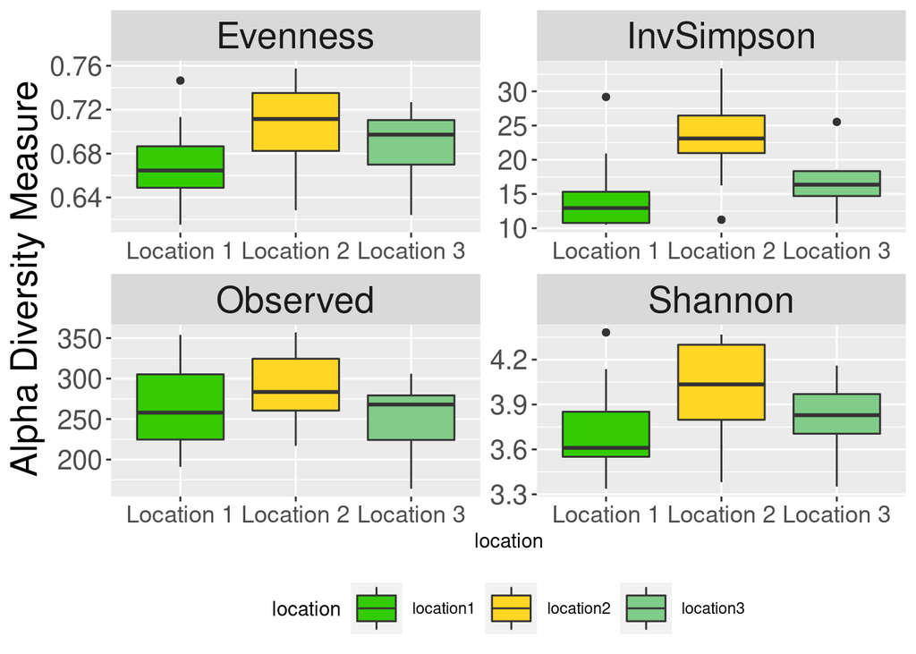

```r
alpha_plot_table <- tidyr::gather(alpha_diversity_table, key = "Measure", value = "Value", Observed, Shannon, InvSimpson, Evenness)

alpha_graphic <- ggplot(data = alpha_plot_table, aes(x = location, y = Value)) +
  facet_wrap(~Measure, scale = "free") +
  geom_boxplot()+
  theme(axis.text.x = element_text(size=13),
        legend.position="bottom", strip.text = element_text(size = 20), axis.text.y = element_text(size=15), axis.title.y=element_text(size=20)) +
  scale_x_discrete(limits=c("location1",
                            "location2","location3"), breaks=c("location1",
                            "location2","location3"),   ##With breaks and labels you can change the name displayed on labels
                   labels=c("Location 1",
                            "Location 2","Location 3")) +

  aes(fill=location)+ scale_fill_manual(values = c( "location1"= "#33CC00",
                                                          "location2"= "#ffd624", "location3"="#80CC88"), na.translate=FALSE) +
  theme(legend.key.size = unit(1, 'cm')) +
  ylab("Alpha Diversity Measure")

alpha_graphic
```

```r
#use ggsave for saving ggplots
#ggsave("alpha_plot.tiff", plot = alpha_graphic,width = 17, height = 30, units = "cm", dpi = 800 )
```

## $\beta$ diversity analysis

### Data preparation

For $\beta$ diversity analysis, we first normalize data making use of `edgeR`^8 package. This is implemented to account for differences in library sizes between samples, as well as for compositionality.

```r
library(edgeR); packageVersion("edgeR")
```

```
#> [1] '3.34.1'
```

```r
edgeR <- DGEList(counts = OTU, samples = metadata.micro, genes = tax)
edgeR <- calcNormFactors(edgeR)

##EXTRACT NORMALIZED COUNTS
ASV_norm <- cpm(edgeR, normalized.lib.sizes=T, log=F)

##CREATE NORMALIZED PHYLOSEQ OBJECT
phy_OTU_norm<-otu_table(as.data.frame(ASV_norm,row.names=F), taxa_are_rows = T)
phy_taxonomy_norm<-tax_table(as.matrix(tax))
phy_metadata_norm<-sample_data(metadata.micro)

##Add taxa names
taxa_names(phy_OTU_norm)<- taxa_names(phy_taxonomy_norm)
#Check
identical(rownames(ASV_norm), rownames(tax))
```

```
#> [1] TRUE
```

```r
##Merge
normalized_phyloseq<-phyloseq(phy_OTU_norm,phy_taxonomy_norm,phy_metadata_norm,tree_root)
```

Once we have a normalized phyloseq object, it is possible to analyze $\beta$ diversity. A distance method will give us a measure of dissimilarities between replicates. Then, PERMANOVA tests wheter differences between groups are significant or not. We will make use of `Permanova` function from `micro4all`, in order to implement different kind of distance measures at once.

```r
permanova<- Permanova(normalized_phyloseq,distances = c("bray", "unifrac", "wunifrac"), formula = "location")


permanova[[1]]
```

```
#>            Df SumsOfSqs    MeanSqs  F.Model        R2 Pr(>F) distances
#> location    2 1.4239259 0.71196294 4.694553 0.3089629  0.001      bray
#> Residuals  21 3.1848021 0.15165724       NA 0.6910371     NA      bray
#> Total      23 4.6087280         NA       NA 1.0000000     NA      bray
#> location1   2 0.5400315 0.27001574 2.853490 0.2136887  0.005   unifrac
#> Residuals1 21 1.9871565 0.09462650       NA 0.7863113     NA   unifrac
#> Total1     23 2.5271880         NA       NA 1.0000000     NA   unifrac
#> location2   2 0.1356300 0.06781501 2.011679 0.1607841  0.042  wunifrac
#> Residuals2 21 0.7079239 0.03371066       NA 0.8392159     NA  wunifrac
#> Total2     23 0.8435539         NA       NA 1.0000000     NA  wunifrac
```

Bray-Curtis distance seems to explained the most variance (expressed as R^2 in the above table). Nevertheless, another test is necessary to confirm no differences are found between dispersion. If significant differences are to be found with a betadisper test, then differences found with PERMANOVA could be only due to distinct dispersion and further graphic representation would be needed.

Again, we can loop over distances measures thanks to `micro4all`

```r
betadisper<- Betadispersion(location_phyloseq,distances = c("bray", "unifrac", "wunifrac"), formula = "location")
betadisper
```

```
#> [[1]]
#>            Df      Sum Sq     Mean Sq         F N.Perm Pr(>F) distances
#> Groups      2 0.009477442 0.004738721 0.7057149    999  0.523      bray
#> Residuals  21 0.141010413 0.006714782        NA     NA     NA      bray
#> Groups1     2 0.005478824 0.002739412 0.5283464    999  0.616   unifrac
#> Residuals1 21 0.108882461 0.005184879        NA     NA     NA   unifrac
#> Groups2     2 0.005550513 0.002775257 1.0645862    999  0.378  wunifrac
#> Residuals2 21 0.054744637 0.002606887        NA     NA     NA  wunifrac
#>
#> [[2]]
#> [[2]]$bray
#>
#> Permutation test for homogeneity of multivariate dispersions
#> Permutation: free
#> Number of permutations: 999
#>
#> Response: Distances
#>           Df   Sum Sq   Mean Sq      F N.Perm Pr(>F)
#> Groups     2 0.009477 0.0047387 0.7057    999  0.523
#> Residuals 21 0.141010 0.0067148
#>
#> [[2]]$unifrac
#>
#> Permutation test for homogeneity of multivariate dispersions
#> Permutation: free
#> Number of permutations: 999
#>
#> Response: Distances
#>           Df   Sum Sq   Mean Sq      F N.Perm Pr(>F)
#> Groups     2 0.005479 0.0027394 0.5283    999  0.616
#> Residuals 21 0.108882 0.0051849
#>
#> [[2]]$wunifrac
#>
#> Permutation test for homogeneity of multivariate dispersions
#> Permutation: free
#> Number of permutations: 999
#>
#> Response: Distances
#>           Df   Sum Sq   Mean Sq      F N.Perm Pr(>F)
#> Groups     2 0.005551 0.0027753 1.0646    999  0.378
#> Residuals 21 0.054745 0.0026069
```

In this example, dispersion was not statistically significant different between the three groups.

But, which groups are distinct? We can make a `pairwiseAdonis` test to check for differences. Again, `micro4all`gives us the option to loop over distances

```r
pairwise<- PairwiseAdonisFun(normalized_phyloseq,distances = c("bray", "unifrac", "wunifrac"), formula = "location", pval=0.05)


pairwise
```

```
#>                    pairs Df SumsOfSqs  F.Model        R2 p.value p.adjusted sig distances
#> 1 location1 vs location2  1 0.3731350 2.320962 0.1422074   0.002     0.0020   *      bray
#> 2 location1 vs location3  1 0.8949239 6.055738 0.3019454   0.001     0.0015   *      bray
#> 3 location2 vs location3  1 0.8678299 5.926861 0.2974307   0.001     0.0015   *      bray
#> 4 location1 vs location2  1 0.2572798 2.756721 0.1645144   0.033     0.0380   .   unifrac
#> 5 location1 vs location3  1 0.2960299 3.005412 0.1767327   0.008     0.0240   .   unifrac
#> 6 location2 vs location3  1 0.2567375 2.789038 0.1661225   0.038     0.0380   .   unifrac
```

It seems that, according to statistical analysis used and with Bray-Curtis distances, all groups are grouped distinctively. For visualization, we can use PCoA and NMDS with every measure. Here it is a loop for producing every possible graphic. It assigns each graphic to elements of a list.

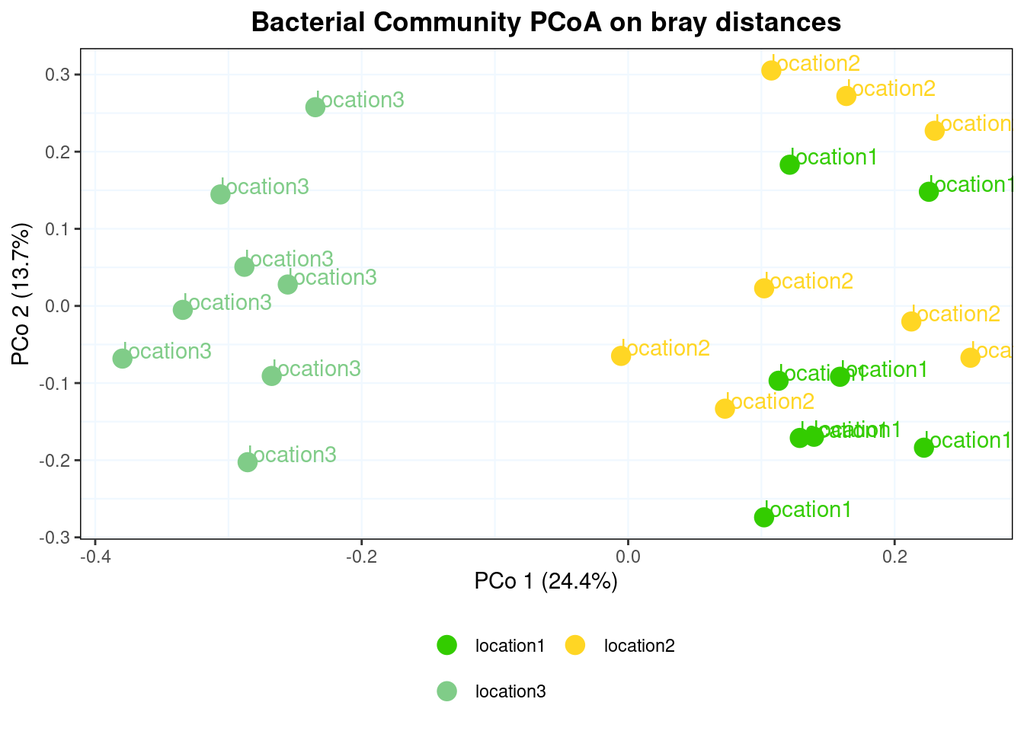

```r
var_list <-  c("bray", "unifrac", "wunifrac")
plot_type <-  c("PCoA", "NMDS")
combination_plot <- purrr::cross2(plot_type,var_list )


# Make plots.
plot_list = list()

for (i in 1:length(combination_plot)){
      pcoa <- ordinate(normalized_phyloseq,combination_plot[[i]][[1]],combination_plot[[i]][[2]])
      plot = plot_ordination(normalized_phyloseq, pcoa, type="samples", color="location")+
        geom_text(aes(label=location), hjust=0, vjust=0, show.legend=FALSE)+
        geom_point(size=4)
      if (combination_plot[[i]][[1]]=="NMDS"){
        plot= plot + xlab(paste("Axis 1"))+
        ylab(paste("Axis 2"))+
          theme(legend.position="bottom", plot.title = element_text(face="bold", hjust = 0.5), legend.title = element_blank(), legend.key = element_blank(),
                panel.border = element_rect(linetype = "solid", fill = NA),
                panel.background = element_rect(fill="white", colour="white"),
                panel.grid.major = element_line(colour="aliceblue", size=0.4),
                panel.grid.minor= element_line(colour = "aliceblue", size =0.4))+

          scale_color_manual(values=c("location1"= "#33CC00",
                                                          "location2"= "#ffd624", "location3"="#80CC88"))+
          guides(color=guide_legend(nrow=2,byrow=TRUE))+
          guides(shape=guide_legend(nrow=2,byrow=TRUE))+
          theme(plot.title = element_text(face="bold", hjust = 0.5))+
          ggtitle(paste("Bacterial Community", combination_plot[[i]][[1]], "on", combination_plot[[i]][[2]], "distances", round(pcoa$stress, digits = 3)))

        plot_list[[i]] = plot

      }
      else {
        plot= plot +   xlab(paste("PCo 1", paste("(",round(pcoa$values[1,2]*100,1),"%",")",sep=""),sep=" "))+
          ylab(paste("PCo 2", paste("(",round(pcoa$values[2,2]*100,1),"%",")",sep=""),sep=" "))+

          theme(legend.position="bottom", plot.title = element_text(face="bold", hjust = 0.5), legend.title = element_blank(), legend.key = element_blank(),
                panel.border = element_rect(linetype = "solid", fill = NA),
                panel.background = element_rect(fill="white", colour="white"),
                panel.grid.major = element_line(colour="aliceblue", size=0.4),
                panel.grid.minor= element_line(colour = "aliceblue", size =0.4))+

          scale_color_manual(values=c("location1"= "#33CC00",
                                                          "location2"= "#ffd624", "location3"="#80CC88"))+
          guides(color=guide_legend(nrow=2,byrow=TRUE))+
          guides(shape=guide_legend(nrow=2,byrow=TRUE))+
          theme(plot.title = element_text(face="bold", hjust = 0.5))+
          ggtitle(paste("Bacterial Community", combination_plot[[i]][[1]], "on", combination_plot[[i]][[2]], "distances"))

        plot_list[[i]] = plot

      }

       }



plot_list[[1]]
```

Going deeper in the analysis, we can get a bar plot with the variance explained by every axis. However, we should be careful in this sense because we are using non-Euclidian distances. This is why we can find negative eigenvalues (imaginary dimensions). If we want to visualize corrected eigenvalues, select element `Corr_eig` in `pcoa`.

```r
PCOA_Wunifrac  <-  ordinate(normalized_phyloseq, "PCoA", "wunifrac", formula="location")
length(PCOA_Wunifrac$values$Relative_eig)
```

```
#> [1] 24
```

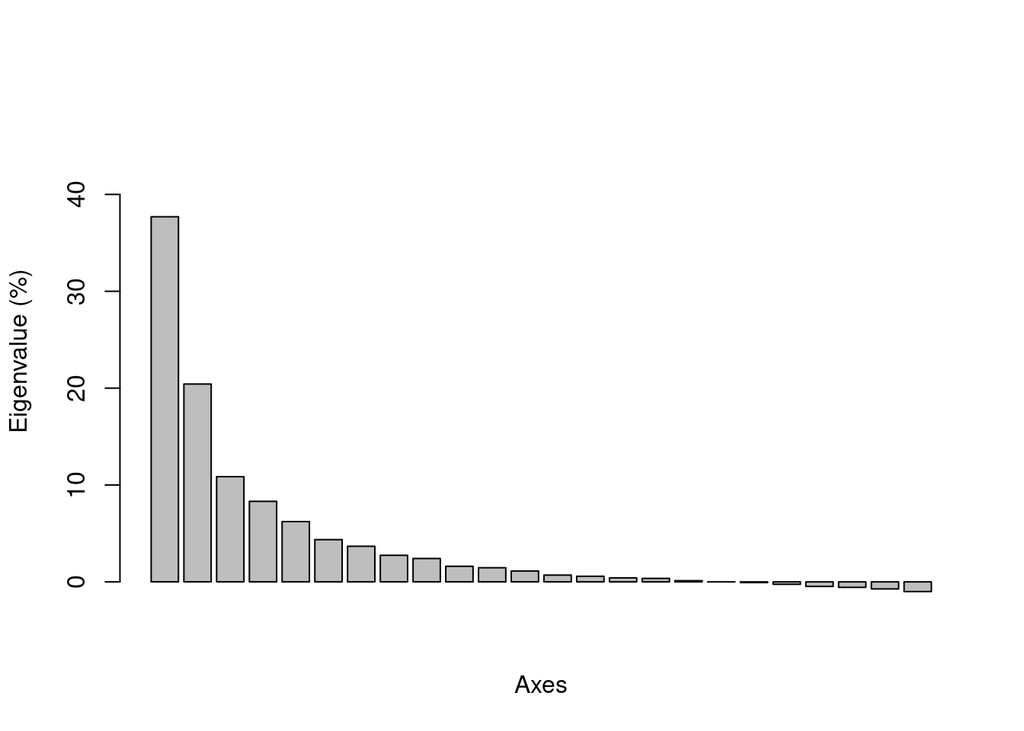

```r
barplot(100*PCOA_Wunifrac$values$Relative_eig, ylim=c(0,10+100*max(PCOA_Wunifrac$values$Relative_eig)),
        xlab=c("Axes"),ylab = c("Eigenvalue (%)"),axisnames = T,
        axis.lty = 1)
```

And with the next line, we can get the percentage of variance explained by the number of axes we choose.

```r
sum(PCOA_Wunifrac$values$Relative_eig[1:10])
```

```
#> [1] 0.9832173
```

## PRODUCE TABLES WITH RELATIVE ABUNDANCE

For further analysis, or to represent data, it is useful to have tables with relative abundance at different levels. First, we usually produce a table with relative abundance by sample.

```r
##CALCULATE RELAIVE ABUNDANCE
sample_relabun <- transform_sample_counts(location_phyloseq, function(x){x/sum(x)}*100)
##CONSTRUCT THE TABLE
OTU_sample <-  as.data.frame((otu_table(sample_relabun)))
taxonomy_sample <- as.data.frame(tax_table(sample_relabun))
identical(rownames(OTU_sample),rownames(taxonomy_sample))
```

```
#> [1] TRUE
```

```r
sample_relabun_table  <- cbind(taxonomy_sample, OTU_sample)
#SORT IT
sample_relabun_table <- sample_relabun_table[sort(sample_relabun_table$ASV_names, decreasing = FALSE),]

#Check relative abundance sums 100
colSums(sample_relabun_table[,8:ncol(sample_relabun_table)])
```

```
#> L1_1 L1_2 L1_3 L1_4 L1_5 L1_6 L1_7 L1_8 L2_1 L2_2 L2_3 L2_4 L2_5 L2_6 L2_7 L2_8 L3_1 L3_2 L3_3 L3_4 L3_5
#>  100  100  100  100  100  100  100  100  100  100  100  100  100  100  100  100  100  100  100  100  100
#> L3_6 L3_7 L3_8
#>  100  100  100
```

```r
head(sample_relabun_table)
```

```
#>          Kingdom         Phylum          Class             Order                Family             Genus
#> ASV0002 Bacteria Actinobacteria Actinobacteria  Streptomycetales     Streptomycetaceae      Streptomyces
#> ASV0003 Bacteria   unclassified   unclassified      unclassified          unclassified      unclassified
#> ASV0006 Bacteria Actinobacteria Actinobacteria Pseudonocardiales    Pseudonocardiaceae      unclassified
#> ASV0007 Bacteria Actinobacteria Actinobacteria Pseudonocardiales    Pseudonocardiaceae    Pseudonocardia
#> ASV0008 Bacteria Actinobacteria Actinobacteria Pseudonocardiales    Pseudonocardiaceae      unclassified
#> ASV0009 Bacteria Actinobacteria Actinobacteria     Micrococcales Promicromonosporaceae Promicromonospora
#>         ASV_names       L1_1      L1_2      L1_3      L1_4       L1_5       L1_6       L1_7      L1_8
#> ASV0002   ASV0002 14.0259740  4.948270 10.952151 22.313534  9.6628190  7.0975536 20.6363428 5.6656324
#> ASV0003   ASV0003  3.8411995 27.602569 26.490992 15.422819 10.6662492 24.8489882 10.4077678 5.6544170
#> ASV0006   ASV0006  2.6185197  6.432394  7.262470 10.977484 19.6544215  6.2569214  5.3903694 1.0486373
#> ASV0007   ASV0007  1.2754725  2.839814  2.015094  0.859669  0.4583043  1.7492198  2.1961536 0.8598452
#> ASV0008   ASV0008 11.1772780  2.186943  2.597007  1.084608  7.1506853  4.2509816  3.0733649 6.4675315
#> ASV0009   ASV0009  0.1942773  1.516233  2.325109  1.899735  0.1053246  0.4681365  0.3458838 3.6524730
#>               L2_1       L2_2       L2_3      L2_4       L2_5       L2_6     L2_7     L2_8       L3_1
#> ASV0002  7.6127858  7.2929059 11.3118073 2.9898305 14.3100149 12.8953771 8.765605 9.173451 13.8188173
#> ASV0003 10.5838812  3.6570460 22.9219949 7.1423729  1.5038757  0.9215745 9.539711 9.168759  8.6681200
#> ASV0006  6.6658396  4.5501214  7.4222080 6.9779661  1.9001411  1.7881545 6.927105 5.471224  0.3650645
#> ASV0007  1.9517843  0.2998647  0.5594629 1.7525424  0.6011637  1.3865280 3.936933 3.411304 14.1804215
#> ASV0008 14.2972336 12.1673376  7.5554135 1.3322034  4.3627858  8.9107756 1.821425 6.151608  0.0000000
#> ASV0009  0.2005541  7.8307068  0.1651748 0.5050847  7.1656390  2.5347465 1.170645 1.489806  7.2961002
#>              L3_2        L3_3       L3_4      L3_5        L3_6       L3_7        L3_8
#> ASV0002  5.119454 17.81884876  7.9539864  9.022696 20.07945492 19.8636100  5.89336358
#> ASV0003 12.056144 10.44958616 11.3487805  3.249411 14.51547449  9.8302380 22.15541690
#> ASV0006  1.428475  0.60665914  0.7871987  1.583364  2.57160554  0.1414684  0.84798639
#> ASV0007 15.753905  5.74680211  9.3948410  4.601265 16.24554134  3.6437174 12.75666478
#> ASV0008  0.000000  0.00000000  0.0000000  0.000000  0.00000000  0.0000000  0.00000000
#> ASV0009  1.265737  0.03291949  1.8742825 21.551118  0.01922297  0.5821967  0.02836075
```

Of course, we can do it at genus level or phylum level

```r
#Glom phyloseq at taxonomical level

location_phyloseq_genus <- tax_glom(location_phyloseq, taxrank = "Genus")
sample_relabun_genus <- transform_sample_counts(location_phyloseq_genus, function(x){x/sum(x)}*100)
##CONSTRUCT THE TABLE
OTU_sample_genus <-  as.data.frame((otu_table(sample_relabun_genus)))
taxonomy_sample_genus  <- as.data.frame(tax_table(sample_relabun_genus)[,-7])
identical(rownames(OTU_sample_genus),rownames(taxonomy_sample_genus))
```

```
#> [1] TRUE
```

```r
sample_table_genus  <- cbind(taxonomy_sample_genus, OTU_sample_genus)
```

Furhtermore, we would like to have all unclassifieds at genus level grouped together

```r
##Agglomerate unclassified in out table
sample_table_genus_unclass <- sample_table_genus %>% subset(Genus=="unclassified", select=c(7:ncol(sample_table_genus))) %>%
  colSums() %>%  t() %>% as.data.frame() %>% cbind(Kingdom="unclassified", Phylum="unclassified", Class="unclassified",
                                                   Order="unclassified", Family="unclassified", Genus="unclassified",  .)

sample_table_genus_final <- rbind(subset(sample_table_genus, Genus!="unclassified"), sample_table_genus_unclass)

#Check relative abundance sums 100
colSums(sample_table_genus_final[,8:ncol(sample_table_genus_final)])
```

```
#> L1_2 L1_3 L1_4 L1_5 L1_6 L1_7 L1_8 L2_1 L2_2 L2_3 L2_4 L2_5 L2_6 L2_7 L2_8 L3_1 L3_2 L3_3 L3_4 L3_5 L3_6
#>  100  100  100  100  100  100  100  100  100  100  100  100  100  100  100  100  100  100  100  100  100
#> L3_7 L3_8
#>  100  100
```

```r
head(sample_table_genus_final)
```

```
#>          Kingdom         Phylum          Class             Order             Family           Genus
#> ASV0021 Bacteria Actinobacteria Actinobacteria Pseudonocardiales Pseudonocardiaceae Actinophytocola
#> ASV0494 Bacteria Actinobacteria Actinobacteria      Jiangellales      Jiangellaceae       Jiangella
#> ASV0576 Bacteria Actinobacteria Actinobacteria Pseudonocardiales Pseudonocardiaceae      Crossiella
#> ASV0139 Bacteria Actinobacteria Coriobacteriia  Coriobacteriales       Atopobiaceae     Fannyhessea
#> ASV0457 Bacteria Actinobacteria Coriobacteriia  Coriobacteriales  Coriobacteriaceae     Collinsella
#> ASV0257 Bacteria Actinobacteria Acidimicrobiia  Acidimicrobiales Ilumatobacteraceae   Ilumatobacter
#>               L1_1       L1_2       L1_3       L1_4       L1_5       L1_6       L1_7       L1_8       L2_1
#> ASV0021 0.38221941 1.65180164 1.19431810 3.83733102 1.50158699 0.43793416 1.86693893 0.24486897 3.21300087
#> ASV0494 0.05279274 0.00000000 0.00000000 0.01336273 0.00000000 0.04782040 0.04167274 0.04486149 0.00000000
#> ASV0576 0.00000000 0.00000000 0.00000000 0.00000000 0.00000000 0.00000000 0.00000000 0.00000000 0.01860811
#> ASV0139 0.11403231 0.00000000 0.00000000 0.00000000 0.15798688 0.00000000 0.00000000 0.06916146 0.29152711
#> ASV0457 0.01055855 0.00000000 0.00000000 0.00000000 0.02988941 0.00000000 0.00000000 0.02990766 0.06616218
#> ASV0257 0.08235667 0.02497324 0.01778772 0.01781698 0.06689534 0.07550589 0.05834184 0.43739953 0.00000000
#>               L2_2       L2_3        L2_4       L2_5      L2_6       L2_7       L2_8       L3_1      L3_2
#> ASV0021 1.70303613 1.80360188 2.610169492 1.01869213 0.3649635 2.51015065 2.03645919 0.50866812 2.5992812
#> ASV0494 0.01792670 0.05861040 0.000000000 0.06378907 0.0383295 0.00000000 0.00000000 0.00000000 0.0000000
#> ASV0576 0.03748309 0.03463342 0.049152542 0.01933002 0.0283305 0.00000000 0.01876921 0.00000000 0.0000000
#> ASV0139 0.12711657 0.00000000 0.164406780 0.00000000 0.1199880 0.29977612 0.21819206 0.26990553 0.0000000
#> ASV0457 0.02281580 0.00000000 0.022033898 0.00000000 0.0133320 0.03225439 0.05865378 0.01211115 0.0000000
#> ASV0257 0.01140790 0.04262575 0.008474576 0.06572207 0.1016565 0.03604903 0.03988457 0.38928683 0.0610266
#>               L3_3       L3_4        L3_5       L3_6       L3_7       L3_8
#> ASV0021 1.46491723 2.65679545 0.250113688 0.73688033 0.82523215 5.32047646
#> ASV0494 0.00000000 0.00000000 0.006201166 0.00000000 0.00000000 0.00000000
#> ASV0576 0.00000000 0.00000000 0.000000000 0.06621244 0.00000000 0.02268860
#> ASV0139 0.45381866 0.36782794 0.000000000 0.00000000 0.00000000 0.00000000
#> ASV0457 0.06348758 0.06091418 0.000000000 0.00000000 0.00000000 0.00000000
#> ASV0257 0.13638074 0.22022819 0.740005788 0.01281531 0.05259721 0.02836075
```

Next, we can group it by the variable of interest, in our case, location (at genus level)

```r
otu_genus <- sample_table_genus_final[,7:ncol(sample_table_genus_final)] %>% t() %>% as.data.frame()
#Save TAXonomy data
tax_genus <- sample_table_genus_final[,1:6]

#Calculate OTU mean abundance based on grouping factor (e.g., location)
location_mean <- aggregate(otu_genus, by=list(metadata.micro$location), FUN=mean)%>% column_to_rownames("Group.1") %>% t()
#Calculate OTU SD  based on grouping factor (e.g., location) and change colnames
location_SD <- aggregate(otu_genus, by=list(metadata.micro$location), FUN=sd)%>% column_to_rownames("Group.1")  %>% t()  %>%
  as.data.frame() %>% rename_with(.fn= ~paste0(colnames(location_mean), "SD"))
#Merge mean abundance, SD and taxonomy.
genus_location_table <- merge(tax_genus, location_mean, by=0) %>%column_to_rownames("Row.names") %>%
  merge(location_SD, by=0) %>% column_to_rownames("Row.names")

#Check abundances sum 100
colSums(genus_location_table[,7:ncol(genus_location_table)])
```

```
#>   location1   location2   location3 location1SD location2SD location3SD
#>   100.00000   100.00000   100.00000    52.57616    59.22263    66.76547
```

```r
head(genus_location_table)
```

```
#>              Kingdom         Phylum               Class             Order                Family
#> 1       unclassified   unclassified        unclassified      unclassified          unclassified
#> ASV0002     Bacteria Actinobacteria      Actinobacteria  Streptomycetales     Streptomycetaceae
#> ASV0007     Bacteria Actinobacteria      Actinobacteria Pseudonocardiales    Pseudonocardiaceae
#> ASV0009     Bacteria Actinobacteria      Actinobacteria     Micrococcales Promicromonosporaceae
#> ASV0013     Bacteria Actinobacteria      Actinobacteria Pseudonocardiales    Pseudonocardiaceae
#> ASV0020     Bacteria Proteobacteria Alphaproteobacteria       Rhizobiales     Bradyrhizobiaceae
#>                     Genus location1 location2 location3 location1SD location2SD location3SD
#> 1            unclassified 45.714742 44.703563 25.544420   9.2007816  12.0239769   7.6266925
#> ASV0002      Streptomyces 18.118573 13.411664 17.534687   8.2783608   5.4710914   9.2352406
#> ASV0007    Pseudonocardia  6.182464  6.157338 16.299546   1.3456363   2.3307788   7.0052689
#> ASV0009 Promicromonospora  1.443766  2.653470  4.081242   1.4523552   3.0884649   7.4631256
#> ASV0013     Amycolatopsis  2.438443  3.455071  6.021820   1.4474202   1.4470150   3.6713713
#> ASV0020    Bradyrhizobium  1.099444  1.194477  2.044616   0.5702665   0.4245332   0.8529809
```

We can also aggregate by location at ASV level

```r
#Save OTU data
otu_location_ASV <- sample_relabun_table[,8:ncol(sample_relabun_table)] %>% t() %>% as.data.frame()
#Save Taxnomy data
tax_location_ASV <- sample_relabun_table[,1:7]

#Calculate OTU mean abundance based on grouping factor (e.g., PLOT)
location_ASV_mean <- aggregate(otu_location_ASV, by=list(metadata.micro$location), FUN=mean)%>% column_to_rownames("Group.1") %>% t()
#Calculate OTU SD  based on grouping factor (e.g., PLOT) and change colnames
location_ASV_SD <- aggregate(otu_location_ASV, by=list(metadata.micro$location), FUN=sd)%>% column_to_rownames("Group.1")  %>% t()  %>%
  as.data.frame() %>% rename_with(.fn= ~paste0(colnames(location_ASV_mean), "SD"))

#Merge mean abundance, SD and taxonomy.
ASV_location_table <- merge(tax_location_ASV, location_ASV_mean, by=0) %>%column_to_rownames("Row.names") %>%
  merge(location_ASV_SD, by=0) %>% column_to_rownames("Row.names")

#Check abundances sum 100
colSums(ASV_location_table[,8:ncol(ASV_location_table)])
```

```
#>   location1   location2   location3 location1SD location2SD location3SD
#>   100.00000   100.00000   100.00000   111.49391   115.77772    99.22682
```

## Taxonomical profile graphics

Usually, taxonomical profiles are interesting graphics to present when publishing data. They give a visual idea of the main taxonomical groups present in our comminities.

```r
taxonomical_genus_location <- genus_location_table %>% select(6:9) %>% #select columns with genera and abundance
  pivot_longer(!Genus, names_to="Samples", values_to="Abundance") %>%
  mutate(Genus = case_when(Abundance<= 1.0 & Genus!="unclassified" ~ "Other genera (<1%)", TRUE ~ as.character(Genus)))

#Reorder table (first, descendant, then unclassified and other phyla)
taxonomical_genus_location <- taxonomical_genus_location %>% filter(Abundance > 1 & Genus!="unclassified") %>%
  arrange(desc(Abundance))

taxonomical_genus_location <- rbind(taxonomical_genus_location, filter(taxonomical_genus_location,Genus=="unclassified"|Genus=="Other genera (<1%)"))


head(taxonomical_genus_location)
```

```
#> # A tibble: 6 × 3
#>   Genus          Samples   Abundance
#>   <chr>          <chr>         <dbl>
#> 1 Streptomyces   location1     18.1
#> 2 Streptomyces   location3     17.5
#> 3 Pseudonocardia location3     16.3
#> 4 Streptomyces   location2     13.4
#> 5 Pseudonocardia location1      6.18
#> 6 Pseudonocardia location2      6.16
```

Afterwards, we create an expression to introduce in ggplot, in a way that phylum and genera names are writting in italics.

```r
library(gdata)
```

```r
#Get labels for location
location_label <- levels(as.factor(unique(taxonomical_genus_location$Samples)))

#Get unique names for genera
unique_genera <- unique(as.vector(taxonomical_genus_location$Genus))

#REORDER FACTORS LEVELS IN DATA FRAME
taxonomical_genus_location$Genus=reorder.factor(taxonomical_genus_location$Genus,new.order=rev(unique_genera))

sorted_labels_genus<- as.data.frame(unique_genera)

##CREATE AN EXPRESSION FOR GGPLOT WITH ITALICS WHEN NEEDED.
sorted_labels_ggplot <- sapply(sorted_labels_genus$unique_genera,
                                           function(x) if (x == "Other phyla (<1%)"|x == "unclassified"|x == "Other genera (<1%)")
                                           {parse(text=paste0("'", as.character(x), "'"))} else {parse(text = paste0("italic('",as.character(x), "')"))})
```

When having to color a great number of objects, `randomcoloR` package can be very useful. You can combine it with package `scales` to display the random generated colors, as well as its codes.

```r
library(randomcoloR);packageVersion("randomcoloR")
```

```
#> [1] '1.1.0.1'
```

```r
library(scales);packageVersion("scales")
```

```
#> [1] '1.1.1'
```

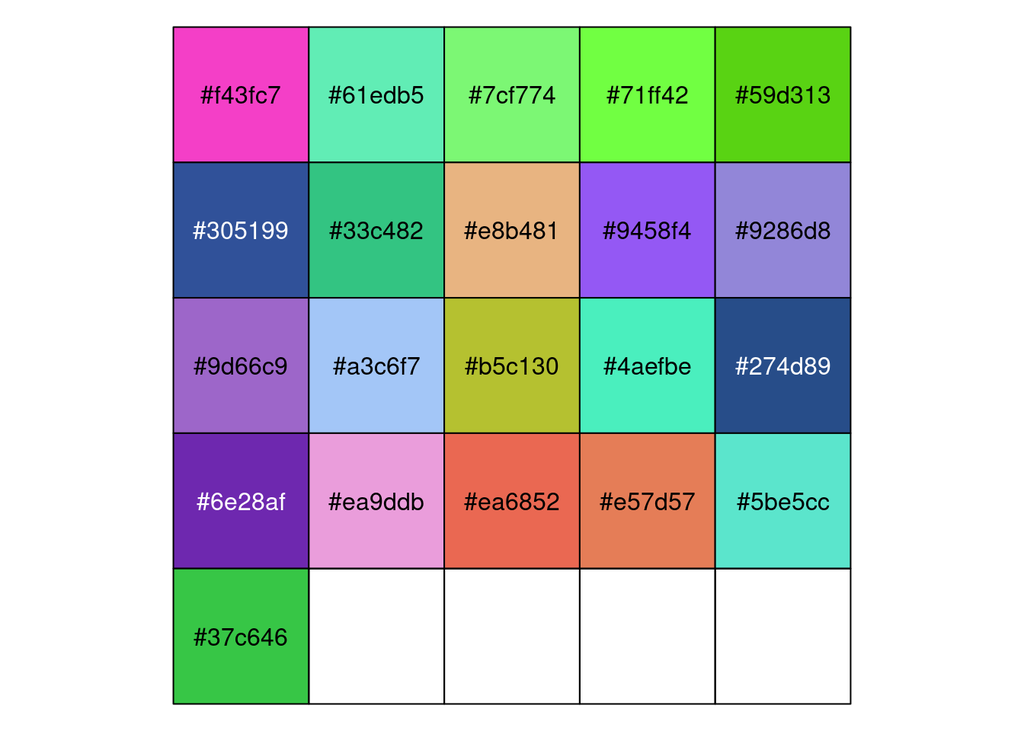

```r
colors_genus <-  randomColor(count=length(unique_genera), hue=c("random"))
show_col(colors_genus)
```

If you want to change some of these colors, it can be easily done as follows:

```r
colors_genus[5] <-  "#448800"
```

In this tutorial, we will use the next palette, because it has been previously optimized to include very distinctive colors

```r
c21 <- c(
  "dodgerblue2", "#E31A1C", # red
  "green4",
  "#6A3D9A", # purple
  "#FF7F00", # orange
  "black", "gold1",
  "skyblue2", "#FB9A99", # lt pink
  "#CAB2D6", # lt purple
  "#FDBF6F", # lt orange
  "gray70", "khaki2",
  "maroon", "steelblue4",
  "darkturquoise", "green1", "yellow4", "yellow3",
  "darkorange4", "brown"
)
```

At last, let’s plot taxonomical profile at genus level!

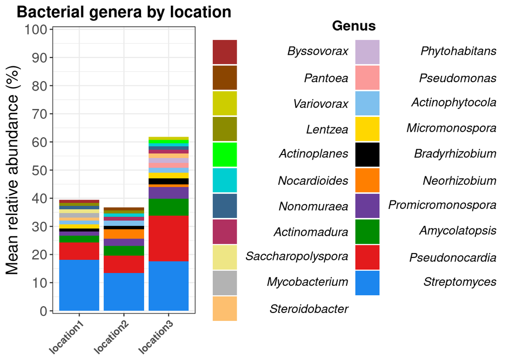

```r
ggplot_title <- "Bacterial genera by location"

ggGenera=ggplot(taxonomical_genus_location, aes(x=Samples, y=Abundance, fill=Genus, order=Genus)) + geom_bar(stat="identity", position="stack")+
  scale_fill_manual(values=c21,
                    breaks=unique_genera,
                    labels=sorted_labels_ggplot)+

  labs(y="Mean relative abundance (%)", x=NULL, fill="Genus",title=ggplot_title)+
  guides(fill = guide_legend(reverse = TRUE))+
  scale_x_discrete(limits=location_label,
                   labels=location_label)+
  scale_y_continuous(expand=c(0.01,0.01),
                     breaks=c(0,10,20,30,40,50,60,70,80,90,100),
                     labels=c("0","10", "20","30","40","50","60","70","80","90","100"),
                     limits = c(NA, 100))+
  theme_bw()+
  theme(panel.border = element_rect(colour="black"), axis.title.x=element_blank(),
        plot.title = element_text(face="bold", hjust = 0.5, size=16), axis.text = element_text(size = 14),
        axis.text.x = element_text(face="bold", size=10, angle = 45, vjust=1, hjust = 1), axis.title.y = element_text(size = 16),
        legend.key.size = unit(0.9, "cm"), legend.text = element_text(size = 12),
        legend.title = element_text(size=14, face="bold"), legend.title.align=0.5)


ggGenera
```

## ANCOM-BC ANALYSIS

There are several methods to perform differential abundance analysis on microbial community data. Among them, we choose ANCOMBC^2, because it is specifically designed for this kind of data, accounting for its compositionality. Unfortunately, when having multiple groups to compare, `ancombc` function only compares the first group against all others. This is a big drawback and requires the user to change the input `phyloseq` object for every other combination between groups. To solve this problem, `micro4all`has implemented the function `ancomloop`. Apart from looping over groups, it also returns a table with ANCOM corrected logarithmic abundances. Let’s see how it works!

```r
library(ANCOMBC);packageVersion("ANCOMBC")
```

```
#> [1] '1.2.2'
```

```r
library(microbiome);packageVersion("microbiome")
```

```
#> [1] '1.14.0'
```

```r
library(car);packageVersion("car")
```

```
#> [1] '3.0.11'
```

```r
library(ggplot2);packageVersion("ggplot2")
```

```
#> [1] '3.3.5'
```

```r
library(gridExtra);packageVersion("gridExtra")
```

```
#> [1] '2.3'
```

```r
ANCOM_location_genus <- ancomloop(input_object_phyloseq = location_phyloseq_genus, grouping = "location", ancom.options = list(global=FALSE, struc_zero=TRUE),out.unclassified = TRUE, tax.level="Genus") #When performing ancombc at genus level, we can filter unclassified genera out with out.unclassified and tax.level arguments
```

```
#> [1] "location1" "location2" "location3"
#> [1] "location2" "location1" "location3"
#> [1] "location3" "location1" "location2"
```

```r
head(ANCOM_location_genus[["location1"]])
```

```
#>          Kingdom         Phylum               Class             Order                Family
#> ASV0002 Bacteria Actinobacteria      Actinobacteria  Streptomycetales     Streptomycetaceae
#> ASV0007 Bacteria Actinobacteria      Actinobacteria Pseudonocardiales    Pseudonocardiaceae
#> ASV0009 Bacteria Actinobacteria      Actinobacteria     Micrococcales Promicromonosporaceae
#> ASV0013 Bacteria Actinobacteria      Actinobacteria Pseudonocardiales    Pseudonocardiaceae
#> ASV0020 Bacteria Proteobacteria Alphaproteobacteria       Rhizobiales     Bradyrhizobiaceae
#> ASV0021 Bacteria Actinobacteria      Actinobacteria Pseudonocardiales    Pseudonocardiaceae
#>                     Genus ASV_names location1MeanLogAbun location2MeanLogAbun location3MeanLogAbun
#> ASV0002      Streptomyces      <NA>             8.918169             8.661286             8.460861
#> ASV0007    Pseudonocardia      <NA>             7.909686             7.896042             8.415824
#> ASV0009 Promicromonospora      <NA>             5.910514             6.400510             5.068504
#> ASV0013     Amycolatopsis      <NA>             6.834763             7.320118             7.376984
#> ASV0020    Bradyrhizobium      <NA>             6.078364             6.263490             6.373811
#> ASV0021   Actinophytocola      <NA>             6.095005             6.631645             5.908298
#>         location1SD location2SD location3SD location1vslocation2_beta location1vslocation2_SE
#> ASV0002   0.6579323   0.6095905   0.6402710                -0.2568829               0.2966303
#> ASV0007   0.3883813   0.4364566   0.7300870                -0.0136443               0.1932187
#> ASV0009   1.2658298   1.3862324   2.4538012                 0.4899962               0.6208331
#> ASV0013   0.9757595   0.4659704   0.8281331                 0.4853547               0.3576102
#> ASV0020   0.4977355   0.3887543   0.3604199                 0.1851260               0.2088695
#> ASV0021   1.3054621   0.8102586   1.1480617                 0.5366397               0.5081408
#>         location1vslocation2_W location1vslocation2_pvalue location1vslocation2_padjusted
#> ASV0002            -0.86600359                   0.3864882                              1
#> ASV0007            -0.07061587                   0.9437035                              1
#> ASV0009             0.78925591                   0.4299624                              1
#> ASV0013             1.35721715                   0.1747122                              1
#> ASV0020             0.88632402                   0.3754429                              1
#> ASV0021             1.05608477                   0.2909295                              1
#>         location1vslocation2_diff location1vslocation3_beta location1vslocation3_SE location1vslocation3_W
#> ASV0002                     FALSE                -0.4573077               0.3036176             -1.5061963
#> ASV0007                     FALSE                 0.5061378               0.2734922              1.8506482
#> ASV0009                     FALSE                -0.8420097               0.9131355             -0.9221081
#> ASV0013                     FALSE                 0.5422211               0.4232570              1.2810681
#> ASV0020                     FALSE                 0.2954464               0.2032356              1.4537139
#> ASV0021                     FALSE                -0.1867070               0.5749448             -0.3247390
#>         location1vslocation3_pvalue location1vslocation3_padjusted location1vslocation3_diff
#> ASV0002                  0.13201680                              1                     FALSE
#> ASV0007                  0.06422018                              1                     FALSE
#> ASV0009                  0.35647217                              1                     FALSE
#> ASV0013                  0.20016973                              1                     FALSE
#> ASV0020                  0.14602565                              1                     FALSE
#> ASV0021                  0.74537858                              1                     FALSE
```

We can filter these results to get only the significant ones and the comparison we would like to analyze

```r
ANCOM_location1_genus <- ANCOM_location_genus[["location1"]]
ANCOM_loc1vsloc2_genus_sig <- ANCOM_location1_genus[,1:19] %>% filter(location1vslocation2_diff,TRUE)
```

### ANCOM-BC graphic

Graphical representation of differential analysis results can be achieved with two approaches: log fold change with corrected abundances or relative abundance without correction. Here, we will show how to accomplish both graphics. For publication purposes, we rather represent both graphics in one figure.

We will start with log fold change. First, we will bind phylum and genus name (this can be replicated when representing ASV).

```r
#Bind phylum name to genus name
graphic_loc1vsloc2_genus<-ANCOM_loc1vsloc2_genus_sig
for (i in 1:nrow(graphic_loc1vsloc2_genus)){
  graphic_loc1vsloc2_genus$Classification[i]<- paste(graphic_loc1vsloc2_genus$Phylum[i],graphic_loc1vsloc2_genus$Genus[i],sep="|")
  }
```

Next, we create a data frame with data (classification and log fold change) and filter out those genera where log fold change is 0 or less than a specific value. Remember, log fold change correspond to `beta` parameter in `res` element from `ancombc` function.

```r
##Create the data frame for representation, with Classification, Log fold change and standard deviation
logfold_df <-  graphic_loc1vsloc2_genus %>% select(Classification, location1vslocation2_beta, location1vslocation2_SE)

colnames(logfold_df)<- c("Genus", "LogFold_location1vslocation2", "SD")

##Filter out 0 log fold change and assign name according to the direction of change
logfold_df  <-  logfold_df %>%
  filter(LogFold_location1vslocation2 != 0) %>% arrange(desc(LogFold_location1vslocation2)) %>%
  mutate(group = ifelse(LogFold_location1vslocation2 > 0, "Location1", "Location2"))

logfold_df$Genus = factor(logfold_df$Genus, levels = logfold_df$Genus)

#FILTER WHEN NEEDED. This can be used to filter the results according to log fold change level
range(logfold_df$LogFold_location1vslocation2)
```

```
#> [1] -3.118498  2.284971
```

```r
logfold_df_filtered <- rbind(logfold_df[which(logfold_df$LogFold_location1vslocation2>=1.5),], logfold_df[which(logfold_df$LogFold_location1vslocation2<=-1.5),])#If not filtering, use in plotting logfold_df
```

Now that we have prepared all data, we can use `ggplot` for plotting log fold change

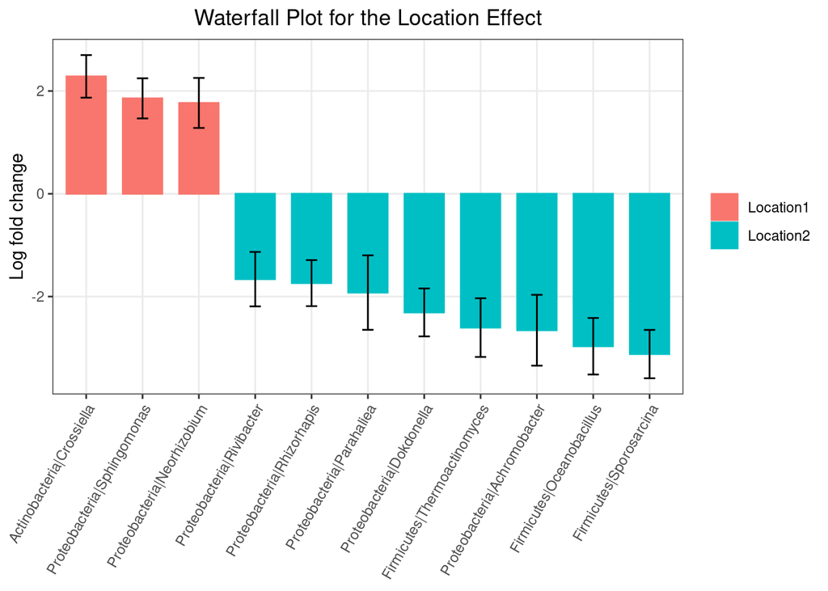

```r
waterfall_location1 <-  ggplot(data = logfold_df_filtered,
           aes(x = Genus, y = LogFold_location1vslocation2, fill = group, color = group)) +
  geom_bar(stat = "identity", width = 0.7,
           position = position_dodge(width = 0.4)) +
  geom_errorbar(aes(ymin = LogFold_location1vslocation2 - SD, ymax = LogFold_location1vslocation2 + SD), width = 0.2,
                position = position_dodge(0.05), color = "black") +
  labs(x = NULL, y = "Log fold change",
       title = "Waterfall Plot for the Location Effect") +
  theme_bw() +
  theme(legend.position = "right",
        legend.title =element_blank(),
        plot.title = element_text(hjust = 0.5),
        panel.grid.minor.y = element_blank(),
        axis.text.x = element_text(angle = 60, hjust = 1))
waterfall_location1
```

As we mentioned above, we will also produce a graphic with relative abundance, specifically, a back-to-back plot.

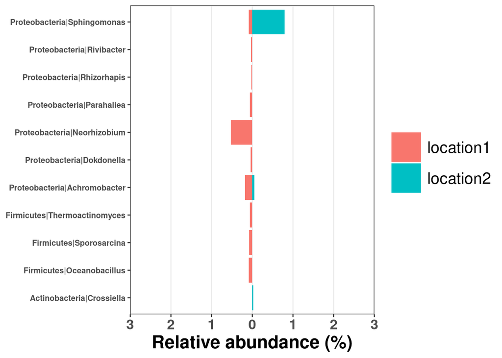

```r
#Again, bind phylum name and genus name
pyramidal_df<- genus_location_table
for (i in 1:nrow(pyramidal_df)){
  pyramidal_df$Classification[i]<- paste(pyramidal_df$Phylum[i],pyramidal_df$Genus[i],sep="|")
  }

#Now, transform it to ggplot format
pyramidal_loc1vsloc2 <- pyramidal_df %>% select(c(13, 7:8)) %>% #select columns with genera and abundance
  pivot_longer(!Classification, names_to="Samples", values_to="Abundance")# %>%

#Filter pyrmaidal_loc1vsloc2 to include only significat genera according to ANCOM
pyramidal_loc1vsloc2_filt <- pyramidal_loc1vsloc2[which(pyramidal_loc1vsloc2$Classification %in%logfold_df_filtered$Genus ),]

#Split table according to location
loc1pyrm <- pyramidal_loc1vsloc2_filt[which(pyramidal_loc1vsloc2_filt$Samples=="location1"),]
loc2pyrm <- pyramidal_loc1vsloc2_filt[which(pyramidal_loc1vsloc2_filt$Samples=="location2"),]


#GRAPHIC
pyramidalggplot=ggplot(data = pyramidal_loc1vsloc2_filt, mapping= aes(x = Classification, y=Abundance, fill = Samples), colour="white")+
  geom_bar(loc1pyrm, stat="identity", mapping=aes(y=-Abundance))+
  geom_bar(data=loc2pyrm, stat="identity")+
  theme_bw()+
  scale_y_continuous(expand=c(0,0), labels=abs, limits=c(-3,3), breaks=seq(-3,3,1))+
  labs(y="Relative abundance (%)")+
  theme(legend.title=element_blank(), axis.title.y=element_blank(), axis.text.y= element_text(size = 8, face="bold"),
        axis.text.x = element_text(size=14, face="bold"), axis.title.x = element_text(size=18, face="bold"), legend.key.size = unit(1.1, "cm"),legend.text = element_text(size = 16), panel.grid.minor.y = element_blank(), panel.grid.major.y = element_blank(),panel.grid.minor.x = element_blank())+
  coord_flip()



pyramidalggplot
```

## Constrained analysis of proximities (CAP).

Microbial communities are greatly influenced by environmental factors. Thus, it is interesting to analyze how these variables relate to community changes. This can be achieved by studying different soil physicochemical parameters and fitting them to an ordination plot. The package `vegan` includes several functions and a very useful [tutorial](https://www.mooreecology.com/uploads/2/4/2/1/24213970/vegantutor.pdf).

We will read the phyloseq file (saved as .RDS) and get the soil physicochemical parameters from metadata

```r
#Read phyloseq and get relative abundance
cap_phyloseq <- readRDS(file = "cap_phyloseq")
cap_phyloseq_rel <- transform_sample_counts(cap_phyloseq,function(x){x/sum(x)}*100)

#Get ASV and metadata
ASV_cap<-as.data.frame(t(otu_table(cap_phyloseq_rel)))
metadata_cap <- as.matrix(sample_data(cap_phyloseq))
metadata_cap <- as.data.frame(metadata_cap)

metadata_cap <- metadata_cap[1:ncol(metadata_cap)-1] #Remove column Season_NucleicAcid
```

Now, we will generate two models. `CAP1` will include all variables to be part of constrained analysis, that is, it will explained the variance due to all variables, and `CAP0`, which is the opposite of `CAP1`, i.e., fully unconstrained.

These two models will be the input for `ordistep` function. The function starts with a model with all unconstrained variables (`CAP0`) and then, in each step, it adds a new variable to the constrained model. Then, it performs a checking step. If the variables left are no longer significant, or add no more explained variance to the model, the function stops. At the end, the output will be the formula with those variables that explained most variance of data. In this way, when having multiple variables, the model can be reduced and remove those that are interdependent.

```r
#Compute CAP1 and CAP0 models
CAP1<-capscale(ASV_cap~Water+ln_P+SOM+N+ph_H2O+ph_KCl+CN+Na_Exch+Clay+Sand+Slime+Texture, data=metadata_cap,distance = "bray")

CAP0<-capscale(ASV_cap~1, data=metadata_cap, distance = "bray")

#Get formula with ordistep
CAP_ordi<-ordistep(CAP0, scope=formula(CAP1))
```

```
#>
#> Start: ASV_cap ~ 1
#>
#>           Df  AIC      F Pr(>F)
#> + ph_KCl  11   28 1.2601  0.040 *
#> + ph_H2O  11   30 1.0487  0.345
#> + Water   15   10 1.0896  0.360
#> + Clay    15   10 1.0955  0.385
#> + ln_P     8   33 1.0101  0.460
#> + Na_Exch 10   33 0.9478  0.700
#> + SOM     14   23 0.8758  0.860
#> + N       13   28 0.8611  0.925
#> + CN      16 -Inf
#> + Sand    16 -Inf
#> + Slime   16 -Inf
#> + Texture 16 -Inf
#> ---
#> Signif. codes:  0 '***' 0.001 '**' 0.01 '*' 0.05 '.' 0.1 ' ' 1
#>
#> Step: ASV_cap ~ ph_KCl
#>
#>          Df    AIC      F Pr(>F)
#> - ph_KCl 11 28.737 1.2601  0.005 **
#> ---
#> Signif. codes:  0 '***' 0.001 '**' 0.01 '*' 0.05 '.' 0.1 ' ' 1
#>
#>           Df  AIC      F Pr(>F)
#> + Na_Exch  4    8 1.0277  0.500
#> + ph_H2O   3   19 0.9191  0.575
#> + ln_P     4   10 0.9176  0.600
#> + Water    5 -Inf
#> + SOM      5 -Inf
#> + N        5 -Inf
#> + CN       5 -Inf
#> + Clay     5 -Inf
#> + Sand     5 -Inf
#> + Slime    5 -Inf
#> + Texture  5 -Inf
```

```r
ef <-  envfit (CAP1~ph_KCl+ph_H2O, data = metadata_cap, perm = 999)
#Now we can adjust pvalues
ef.adj <- ef
pvals.adj <- p.adjust (ef$vectors$pvals, method = 'BH')
ef.adj$vectors$pvals <- pvals.adj
ef.adj
```

```
#>
#> ***VECTORS
#>
#> $pvals
#> numeric(0)
#>
#>
#> ***FACTORS:
#>
#> Centroids:
#>              CAP1    CAP2
#> ph_KCl5.6 -0.5680 -1.0802
#> ph_KCl5.7 -0.6385 -1.0075
#> ph_KCl5.8 -0.4246 -0.1969
#> ph_KCl5.9 -0.5018  0.1034
#> ph_KCl6.0  0.6368  0.3278
#> ph_KCl6.1  0.1524  0.6719
#> ph_KCl6.2 -0.3268  1.0491
#> ph_KCl6.4 -0.0529  1.3443
#> ph_KCl6.5  1.0748  0.1100
#> ph_KCl6.6  0.9464 -0.2098
#> ph_KCl7.0  0.4793 -0.3622
#> ph_KCl7.7  1.6547 -0.9666
#> ph_H2O6.4 -0.0529  1.3443
#> ph_H2O6.5 -0.5446  0.4548
#> ph_H2O6.6 -0.1920 -0.6177
#> ph_H2O6.7 -0.4580  0.6139
#> ph_H2O6.8 -0.3268  1.0491
#> ph_H2O6.9  0.1524  0.6719
#> ph_H2O7.0 -0.6357 -0.3595
#> ph_H2O7.1  1.0748  0.1100
#> ph_H2O7.3  0.6368  0.3278
#> ph_H2O7.7  0.4793 -0.3622
#> ph_H2O7.8  0.9464 -0.2098
#> ph_H2O8.3  1.6547 -0.9666
#>
#> Goodness of fit:
#>            r2 Pr(>r)
#> ph_KCl 0.8180  0.073 .
#> ph_H2O 0.8141  0.088 .
#> ---
#> Signif. codes:  0 '***' 0.001 '**' 0.01 '*' 0.05 '.' 0.1 ' ' 1
#> Permutation: free
#> Number of permutations: 999
```

With `plot_ordination` we can get a graphic representation of ordination and fitted vectors. In this sense, we can visualize the direction of change of environmental variables.

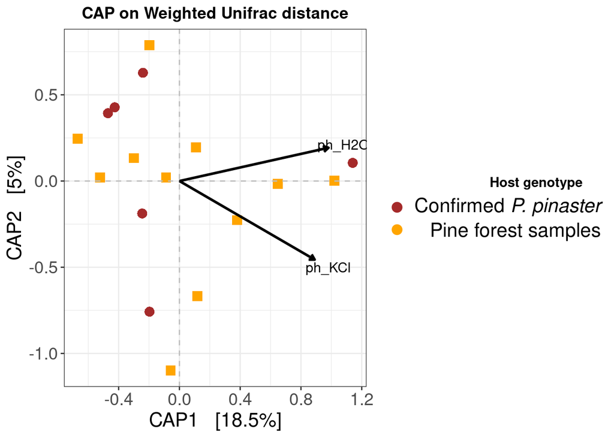

```r
#First, get distance matrix
distance_matrix <- phyloseq::distance(physeq = cap_phyloseq_rel, method = "wunifrac")

#Then, generate ordination with CAP (that is, constrained ordination to ph_KCl)
CAP_wunifrac <-  ordinate(physeq = cap_phyloseq_rel, method = "CAP",distance = distance_matrix,
                                  formula = ~ph_KCl+ph_H2O )

#Produce plot
CAP_wunifrac_plot  <- plot_ordination(physeq = cap_phyloseq_rel, ordination = CAP_wunifrac,
                                             color = "Species", axes = c(1,2)) +
  aes(shape = Species) +
  geom_point(aes(colour = Species), alpha = 1, size = 3.5) +
  scale_shape_manual(values=c("Pinaster"=16,"Other"=15),
                     breaks=c("Pinaster","Other"))+
  scale_color_manual(values = c("Pinaster"="brown", "Other"="orange"),
                     name="Host genotype",
                     breaks=c("Pinaster", "Other"),
                     labels=expression(paste("Confirmed ", italic("P. pinaster")), "Pine forest samples"))+
  guides(shape="none")+
  ggtitle("CAP on Weighted Unifrac distance")+
  theme_bw()+
  theme(legend.key=element_blank(),
        legend.title.align = 0.85,
        legend.title = element_text(face="bold"),
        axis.text = element_text(size=14),
        axis.title = element_text(size = 16),
        plot.title = element_text(hjust=0.5, face="bold"),
        legend.text = element_text(size = 16))+
  geom_hline(aes(yintercept = c(0.00)), lty=2, colour="grey")+
  geom_vline(aes(xintercept = c(0.00)), lty=2, colour="grey")

#Define arrows aesthetic and labels
arrowmat <-  vegan::scores(CAP_wunifrac, display = "bp")
arrowdf <-  data.frame(labels = rownames(arrowmat), arrowmat)
arrow_map  <-  aes(xend = CAP1, yend = CAP2,x = 0, y = 0, shape = NULL, color = NULL, label=labels)
label_map <- aes(x = 1.1 * CAP1, y = 1.1 * CAP2, shape = NULL,color = NULL, label=labels)
arrowhead  <-  arrow(length = unit(0.02, "npc"))

#Introduce them to plot
CAP_wunifrac_plot +
  geom_segment(mapping = arrow_map, size = c(ph_KCl=1,ph_H2O=1), data = arrowdf, color = c(ph_KCl="black",ph_H2O="black"),arrow = arrowhead) +
  geom_text(mapping = label_map, size = 4,data = arrowdf, show.legend = FALSE)
```

## References

1. Callahan BJ, McMurdie PJ, Rosen MJ, Han AW, Johnson AJA, Holmes SP (2016). “DADA2: High-resolution sample inference from Illumina amplicon data.” *Nature Methods*, *13*, 581-583. doi: 10.1038/nmeth.3869 (URL: https://doi.org/10.1038/nmeth.3869).
2. Lin H, Peddada SD (2020). “Analysis of compositions of microbiomes with bias correction.” *Nature communications*, *11*(1), 1–11. doi: 10.1038/s41467-020-17041-7, https://www.nature.com/articles/s41467-020-17041-7.
3. FIGARO: An efficient and objective tool for optimizing microbiome rRNA gene trimming parameters Michael M. Weinstein, Aishani Prem, Mingda Jin, Shuiquan Tang, Jeffrey M. Bhasin bioRxiv 610394; doi: https://doi.org/10.1101/610394
4. MARTIN, Marcel. Cutadapt removes adapter sequences from high-throughput sequencing reads. EMBnet.journal, [S.l.], v. 17, n. 1, p. pp. 10-12, may 2011. ISSN 2226-6089. Available at: http://journal.embnet.org/index.php/embnetjournal/article/view/200. Date accessed: 06 oct. 2021. doi:https://doi.org/10.14806/ej.17.1.200.
5. Katoh K, Standley DM. MAFFT multiple sequence alignment software version 7: improvements in performance and usability. Mol Biol Evol. 2013;30(4):772-780. doi:10.1093/molbev/mst010
6. Price MN, Dehal PS, Arkin AP. FastTree 2–approximately maximum-likelihood trees for large alignments. PLoS One. 2010;5(3):e9490. Published 2010 Mar 10. doi:10.1371/journal.pone.0009490.
7. McMurdie PJ, Holmes S. phyloseq: An R Package for Reproducible Interactive Analysis and Graphics of Microbiome Census Data. Watson M, editor. PLoS One. 2013;8: e61217. pmid:23630581
8. Robinson MD M D S G. edgeR: a Bioconductor package for differential expression analysis of digital gene expression data. Bioinformatics. 2010;26: 139–140. pmid:19910308
9. Wagner H. Vegan: community ecology package. R package version 2.5.2–5. 2018. https://www.mcglinnlab.org/publication/2019-01-01_oksanen_vegan_2019/